# 20230821_missModResults

Jon Januar

## Loading output

```r
# packages
library(ggplot2)
library(here)
library(dplyr)
# true estimates
resultsFiles = list.files(path = here("Output", "20230726_missNetsTrueModels"))

# initialise list
trueCoefList = list()
trueSeList = list()
# loop to load model parameters
for(netInd in 1:6){

  # load in results for each network
  load(here("Output", "20230726_missNetsTrueModels", resultsFiles[[netInd]]))

  # and take the coefficients only
  trueCoefList[[netInd]] = coef(modelres)
  trueSeList[[netInd]] = summary(modelres)$coefficients[,2]
}
# loading in the output results
outputList = list.files(here("Output", "20230814_simMissNets"))

# set up some lists to put in the ergm re-estimations
modelResList = list()
modelSeList = list()
missModelList = list()
propMissList = list()

# hmm... what's the best way to handle this....
# I have specific indices,
# but there are different amounts of each file because re-estimations tend to fail
# especially for some combinations

# some regular expressions
# net1Ind = grep("net1", outputList)
# missMod2Ind = grep("missModel2", outputList)
#
# # check which indices overlap
# net1MissMod2 = missMod2Ind[missMod2Ind %in% net1Ind]

# set a specific index for the network
chosenNetInd = 2

# file list for the chosen network index
chosenNetOutFiles = grep(paste("net", chosenNetInd, sep =""), outputList)

# loop to load
chosenNetOutList = outputList[chosenNetOutFiles]

for(fileInd in 1:length(chosenNetOutList)){
  # load all files
  load(here("Output", "20230814_simMissNets", chosenNetOutList[fileInd]))

  # suppress these version difference warnings.
  suppressWarnings({
  modelResList[[fileInd]] = modelres$coefficients
  modelSeList[[fileInd]] = summary(modelres)$coefficients[,2]

  })

  # regex to get the first number after the specified text
  missModelList[[fileInd]] = as.integer(sub(".*?_missModel.*?(\\d+).*", "\\1", chosenNetOutList[[fileInd]]))
  propMissList[[fileInd]] = as.integer(sub(".*?_prop.*?(\\d+).*", "\\1", chosenNetOutList[[fileInd]]))

}
```

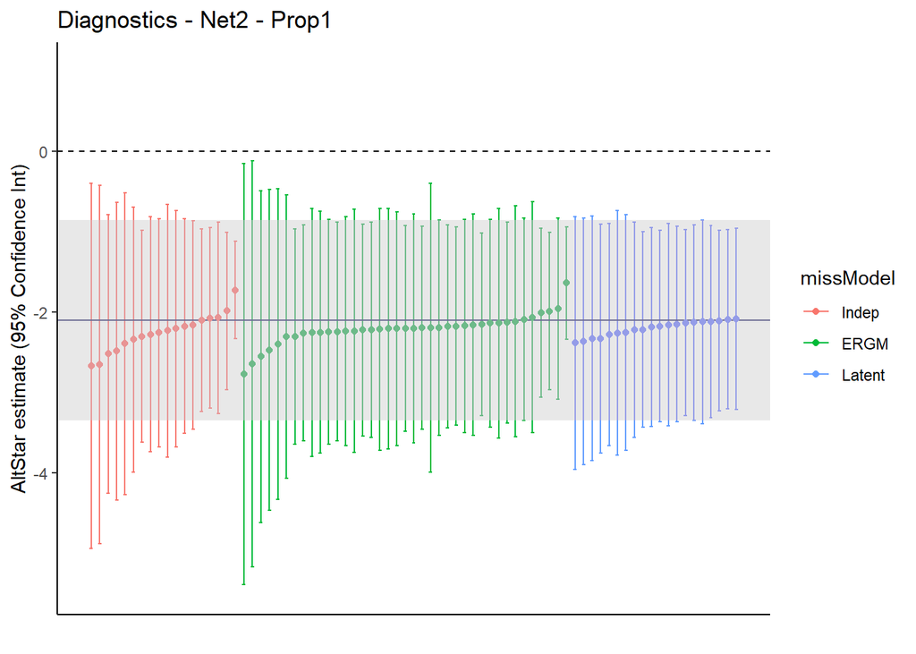

```r
# plotting
# note: I think I should have a plot for each missingness proportion
chosenProp = 1

# there should only be 3 miss props, 1 for 10%, 3.5 for 35%, and 6 for 60%
# subset the lists to only be a single chosen proportion
chosenPropIndex = propMissList == chosenProp

modelResChosenPropList = modelResList[chosenPropIndex]
modelSeChosenPropList = modelSeList[chosenPropIndex]
missModelChosenPropList = missModelList[chosenPropIndex]

## AltStar
# making the dataset
altStarPlotData = data.frame(altStar = c(unlist(lapply(modelResChosenPropList, `[[`, 2) )),
                             SE = c(unlist(lapply(modelSeChosenPropList, `[[`, 2))),
                             missModel = factor(c(unlist(missModelChosenPropList)), levels = c(1,2,3), labels = c("Indep", "ERGM", "Latent")))

# order the plot data
altStarPlotOrd = altStarPlotData[order(altStarPlotData[,"altStar"]),]

# one more ordering with the missing model type
altStarPlotOrd = altStarPlotOrd[order(altStarPlotOrd[,"missModel"]),]



# getting the true altStar value
trueAltStar = trueCoefList[[chosenNetInd]][2]
trueAltStarSE = trueSeList[[chosenNetInd]][2]

# caterpillar?
altStarPlot = ggplot( data = altStarPlotOrd,
                    aes( x = 1:nrow(altStarPlotOrd), y = altStar, col = missModel)) +
             geom_errorbar(aes (ymin = (altStar - 1.96*SE), ymax = (altStar + 1.96*SE), width = 0.4)) +
             xlab("") +
             ylab("AltStar estimate (95% Confidence Int)") +
             geom_hline(yintercept = trueAltStar, col = "darkblue") +
             geom_hline(yintercept = 0, col = "black", lty = 2) +
             geom_point() +
             ggtitle(paste("Diagnostics - Net", chosenNetInd, " - Prop", chosenProp, sep = "")) +
             theme_classic() +
             theme(axis.ticks.x = element_blank(),
                   axis.text.x = element_blank()) +
         #          legend.position = "none") +
             geom_rect(aes(xmin = -Inf,
                           xmax = Inf,
                           ymin = (trueAltStar - 1.96*trueAltStarSE),
                           ymax = (trueAltStar + 1.96*trueAltStarSE)),
                           alpha = 0.01,
                           colour = NA,
                           fill = "grey") +
             ylim(min(altStarPlotData$altStar) - 2*max(abs(altStarPlotData$SE)), max(altStarPlotData$altStar) + 2*max(abs(altStarPlotData$SE)))

altStarPlot
```

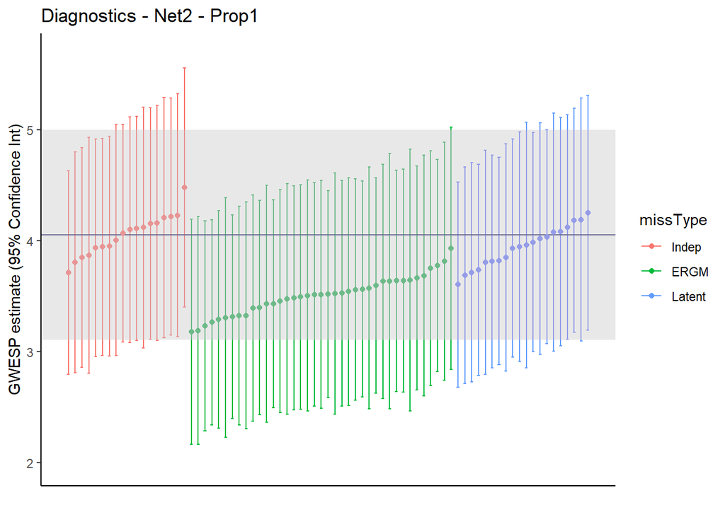

```r
## Gwesp
# making the dataset
gwespPlotData = data.frame(gwesp = c(unlist(lapply(modelResChosenPropList, `[[`, 3) )),
                             SE = c(unlist(lapply(modelSeChosenPropList, `[[`, 3))),
                             missModel = factor(c(unlist(missModelChosenPropList)), levels = c(1,2,3), labels = c("Indep", "ERGM", "Latent")))

# order the plot data
gwespPlotOrd = gwespPlotData[order(gwespPlotData[,"gwesp"]),]

# one more ordering with the missing model type
gwespPlotOrd = gwespPlotOrd[order(gwespPlotOrd[,"missModel"]),]


# getting the true gwdeg value
truegwesp = trueCoefList[[chosenNetInd]][3]
truegwespSE = trueSeList[[chosenNetInd]][3]

# caterpillar?
gwespPlot = ggplot( data = gwespPlotOrd,
                    aes( x = 1:nrow(gwespPlotOrd), y = gwesp, col = missModel)) +
             geom_errorbar(aes (ymin = (gwesp - 1.96*SE), ymax = (gwesp + 1.96*SE), width = 0.4)) +
             xlab("") +
             ylab("GWESP estimate (95% Confidence Int)") +
             labs(col = "missType") +
             geom_hline(yintercept = truegwesp, col = "darkblue") +
             geom_hline(yintercept = 0, col = "black", lty = 2) +
             geom_point() +
             ggtitle(paste("Diagnostics - Net", chosenNetInd, " - Prop", chosenProp, sep = "")) +
             theme_classic() +
             theme(axis.ticks.x = element_blank(),
                   axis.text.x = element_blank()) +
           #        legend.position = "none") +
             geom_rect(aes(xmin = -Inf,
                           xmax = Inf,
                           ymin = (truegwesp - 1.96*truegwespSE),
                           ymax = (truegwesp + 1.96*truegwespSE)),
                           alpha = 0.01,
                           colour = NA,
                           fill = "grey") +
              ylim(min(gwespPlotOrd$gwesp) - 2*max(abs(gwespPlotOrd$SE)), max(gwespPlotOrd$gwesp) + 2*max(abs(gwespPlotOrd$SE)))


gwespPlot
```

### Turn them into functions

I want these functions to take the entire file list, choose specific networks and missingness proportions. The thing is, I might need a few helper functions beforehand to get the right data….

Multiple smaller functions doing very specific things are preferred over one giant function that does a lot of stuff all at once

```r
### Function to turn the data from the extracted lists into plot-friendly format

# start from the list of coefficients and standard errors
# these can have varying rows per model because not all re-estimations converge


prepMissPlot = function(modelResList, modelSeList, missModelList, propMissList, chosenProp, chosenPara){

  ## prepMissPlot(modelResList, modelSeList, missModelList, propMissList, chosenProp, chosenPara) takes
  ## four different containing various estimated values and extracted indices to be used
  ## in making a plot-friendly dataset.
  ##
  ## Input:
  ## - modelResList: A k-long list containing the estimated model parameters for k re-estimated models.
  ##
  ## - modelSeList: A k-long list containing the estimated standard errors for k re-estimated models.
  ##
  ## - missModelList: A k-long list containing the chosen missingness model index for k re-estimated models.
  ##
  ## - propMissList: A k-long list containing the missingness proportion index for k re-estimated models.
  ##
  ## - chosenProp: The specified proportion of missingness to plot. Three possible values here:
  ##               1 = 10%, 3 = 35%, 6 = 60%.
  ##
  ## - chosenPara: The specified parameter to plot. Three possible values here:
  ##               "edges" for edges, "altStar" for alternating stars, "gwesp" for gwesp.
  ##
  ## Output:
  ## - A k x 3 dataframe containing the parameter values, standard error values, and missing model index.
  ##   The dataframe is ordered by parameter value (smallest to largest) for each missingness model.


  ## Check to make sure all the lists are of the same length
  listLengths = lapply(list(modelResList, modelSeList, missModelList, propMissList), FUN = length)

  ## A unit test that spits out an error if there's more than one unique length in the list of lengths
  if( length(unique(listLengths)) != 1 ){
    stop("Lists have differing lengths")
  }

  # subset the lists to only be a single chosen proportion
  chosenPropIndex = propMissList == chosenProp

  modelResChosenPropList = modelResList[chosenPropIndex]
  modelSeChosenPropList = modelSeList[chosenPropIndex]
  missModelChosenPropList = missModelList[chosenPropIndex]

  # Specify indices for the chosen parameter
  # doing it this way because parameter names get very lengthy
  paraIndex = c(1:3)
  modelParaNames = c("edges", "altStar", "gwesp")
  chosenParaIndex = paraIndex[modelParaNames == chosenPara]


  # making the dataset
  plotData = data.frame(parameter = c(unlist(lapply(modelResChosenPropList, `[[`, chosenParaIndex) )),
                        SE = c(unlist(lapply(modelSeChosenPropList, `[[`, chosenParaIndex))),
                        missModel = factor(c(unlist(missModelChosenPropList)), levels = c(1,2,3), labels = c("Indep", "ERGM", "Latent")))

  # order the plot data
  plotOrd = plotData[order(plotData[,"parameter"]),]

  # one more ordering with the missing model type
  plotOrd = plotOrd[order(plotOrd[,"missModel"]),]

  # return the ordered plot data
  return(plotOrd)
}

## actual plotting function

missCaterpillarPlot = function(plotData, truePara, trueSe, chosenPara, chosenNetInd, chosenProp, chosenMiss){

  ## missCaterpillarPlot(plotData, truePara, trueSe, chosenPara, chosenNetInd, chosenProp) is a very specialised
  ## plotting function that produces a caterpillar plot to compare parameter estimates for very specific data.
  ##
  ## Input:
  ## - plotData: Needs to be a k x 3 data frame for k re-estimated models containing parameter values,
  ##             standard error values, and a missing model index. Ordering is optional, but visually
  ##             useful. Ideally from prepMissPlot().
  ##
  ## - truePara: A single float (can technically be integer, but unlikely). Represents the true model estimate.
  ##
  ## - trueSe: A single float (can technically be integer, but unlikely). Represents the true standard error.
  ##
  ## - chosenPara: A string with three (but really two) options. The chosen string is the parameter that is
  ##               plotted. The options, in order, are "edges", "altStar", and "gwesp"
  ##
  ## - chosenNetInd: An integer between 1 to 6 for current purposes. Each integer represents one of the six
  ##                 datasets from UCINet chosen for the current round of re-estimations.
  ##
  ## - chosenProp: A single integer or float with three options representing the proportion of missingness.
  ##               Options are 1 = 10%, 3.5 = 35%, 6 = 60%.
  ##
  ## - chosenMiss: A value to indicate what missingness is saved as (e.g., NA is Peter, 0 is Todd).
  ##               Input should be strings that are directly used for the label.
  ##
  ## Output:
  ## - The output should be a caterpillar plot containing with k datapoints for k re-estimated models.
  ##   Colours are labelled and represent the missingness model used. True values are represented as a
  ##   grey rectangle. All error bars or other depictions of spread are 95% confidence intervals. Plot
  ##   title should also be adaptive to the parameters in the function.



  # caterpillar?
  caterPlot = ggplot( data = plotData,
                      aes( x = 1:nrow(plotData), y = parameter, col = missModel)) +
               geom_errorbar(aes (ymin = (parameter - 1.96*SE), ymax = (parameter + 1.96*SE), width = 0.4)) +
               xlab("") +
               ylab(paste(chosenPara,"estimate (95% Confidence Int)", sep = " ")) +
               labs(col = "missType") +
               geom_hline(yintercept = truePara, col = "darkblue") +
               geom_hline(yintercept = 0, col = "black", lty = 2) +
               geom_point() +
               ggtitle(paste("Diagnostics - Net", chosenNetInd, " - Prop", chosenProp, " - Miss", chosenMiss ,sep = "")) +
               theme_classic() +
               theme(axis.ticks.x = element_blank(),
                     axis.text.x = element_blank()) +
               geom_rect(aes(xmin = -Inf,
                             xmax = Inf,
                             ymin = (truePara - 1.96*trueSe),
                             ymax = (truePara + 1.96*trueSe)),
                             alpha = 0.01,
                             colour = NA,
                             fill = "grey") +
                ylim(min(min(plotData$parameter) - 2*max(abs(plotData$SE)), (truePara - 1.96*trueSe)),
                     max(max(plotData$parameter) + 2*max(abs(plotData$SE)), (truePara + 1.96*trueSe)))

  # print out the plot
  caterPlot


}
```

```r
# test run of the plot function
testPlotData = prepMissPlot(modelResList = modelResList,
                            modelSeList = modelSeList,
                            missModelList = missModelList,
                            propMissList = propMissList,
                            chosenProp = 1,
                            chosenPara = "altStar")

head(testPlotData)
```

```
##    parameter        SE missModel
## 7  -2.667740 1.1581335     Indep
## 6  -2.651687 1.1342895     Indep
## 10 -2.519181 0.8830086     Indep
## 13 -2.484591 0.9431191     Indep
## 14 -2.391916 0.9567384     Indep
## 18 -2.339140 0.8401319     Indep
```

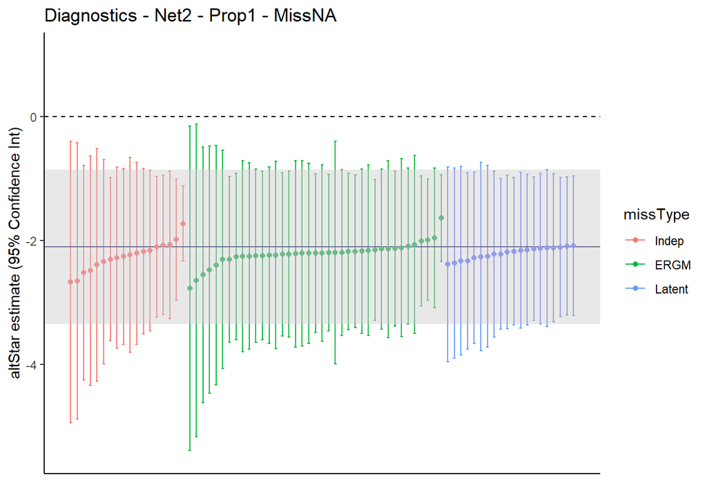

```r
# still need to take out true parameter values
chosenNetwork = 2
chosenPara = 2

tempTruePara = trueCoefList[[chosenNetwork]][chosenPara]
tempTrueSe = trueSeList[[chosenNetwork]][chosenPara]

# and see if the plot here matches the one above
missCaterpillarPlot(plotData = testPlotData,
                    truePara = tempTruePara,
                    trueSe = tempTrueSe,
                    chosenPara = "altStar",
                    chosenNetInd = chosenNetwork,
                    chosenProp = 1,
                    chosenMiss = "NA")
```

```r
## amd gwesp
# test run of the plot function
testPlotData = prepMissPlot(modelResList = modelResList,
                            modelSeList = modelSeList,
                            missModelList = missModelList,
                            propMissList = propMissList,
                            chosenProp = 1,
                            chosenPara = "gwesp")

head(testPlotData)
```

```
##    parameter        SE missModel
## 15  3.713921 0.4693278     Indep
## 3   3.805494 0.5092882     Indep
## 18  3.847856 0.5059986     Indep
## 12  3.867887 0.5433778     Indep
## 17  3.937885 0.5014629     Indep
## 11  3.945033 0.5001198     Indep
```

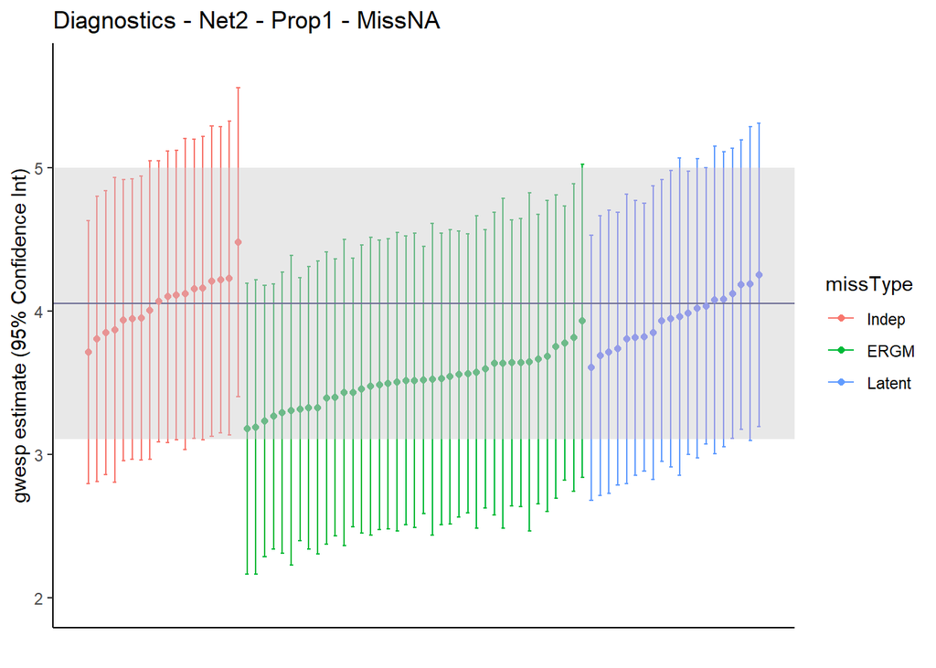

```r
# still need to take out true parameter values
chosenNetwork = 2
chosenPara = 3

tempTruePara = trueCoefList[[chosenNetwork]][chosenPara]
tempTrueSe = trueSeList[[chosenNetwork]][chosenPara]

# and see if the plot here matches the one above
missCaterpillarPlot(plotData = testPlotData,
                    truePara = tempTruePara,
                    trueSe = tempTrueSe,
                    chosenPara = "gwesp",
                    chosenNetInd = chosenNetwork,
                    chosenProp = 1,
                    chosenMiss = "NA")
```

```r
# applying the code above to different reestimations
# set a specific index for the network
chosenNetInd = 4

# file list for the chosen network index
chosenNetOutFiles = grep(paste("net", chosenNetInd, sep =""), outputList)

# loop to load
chosenNetOutList = outputList[chosenNetOutFiles]

for(fileInd in 1:length(chosenNetOutList)){
  # load all files
  load(here("Output", "20230814_simMissNets", chosenNetOutList[fileInd]))

  # suppress these version difference warnings.
  suppressWarnings({
  modelResList[[fileInd]] = modelres$coefficients
  modelSeList[[fileInd]] = summary(modelres)$coefficients[,2]

  })

  # regex to get the first number after the specified text
  missModelList[[fileInd]] = as.integer(sub(".*?_missModel.*?(\\d+).*", "\\1", chosenNetOutList[[fileInd]]))
  propMissList[[fileInd]] = as.integer(sub(".*?_prop.*?(\\d+).*", "\\1", chosenNetOutList[[fileInd]]))

}

# first try with alt star
chosenPara = 2

tempTruePara = trueCoefList[[chosenNetInd]][chosenPara]
tempTrueSe = trueSeList[[chosenNetInd]][chosenPara]


# test run of the plot function
testPlotData = prepMissPlot(modelResList = modelResList,
                            modelSeList = modelSeList,
                            missModelList = missModelList,
                            propMissList = propMissList,
                            chosenProp = 1,
                            chosenPara = "altStar")

head(testPlotData)
```

```
##    parameter        SE missModel
## 29 -2.380226 0.8948844     Indep
## 34 -2.332890 0.8567828     Indep
## 39 -2.225284 0.6481276     Indep
## 12 -2.203632 0.7067738     Indep
## 25 -2.197335 0.7339564     Indep
## 19 -2.194530 0.6131555     Indep
```

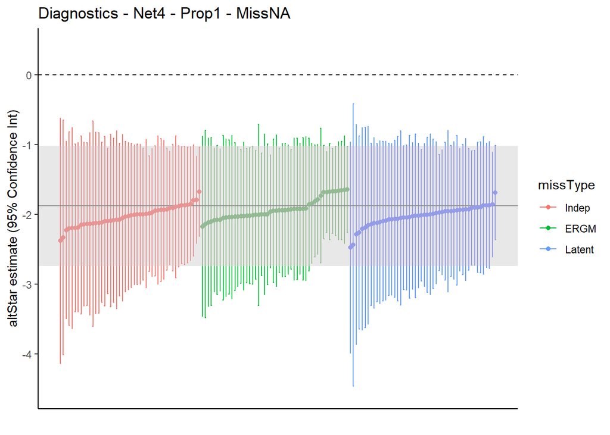

```r
# and see if the plot here matches the one above
missCaterpillarPlot(plotData = testPlotData,
                    truePara = tempTruePara,
                    trueSe = tempTrueSe,
                    chosenPara = "altStar",
                    chosenNetInd = chosenNetInd,
                    chosenProp = 1,
                    chosenMiss = "NA")
```

```r
# still need to take out true parameter values
chosenPara = 3

tempTruePara = trueCoefList[[chosenNetInd]][chosenPara]
tempTrueSe = trueSeList[[chosenNetInd]][chosenPara]


# test run of the plot function
testPlotData = prepMissPlot(modelResList = modelResList,
                            modelSeList = modelSeList,
                            missModelList = missModelList,
                            propMissList = propMissList,
                            chosenProp = 1,
                            chosenPara = "gwesp")

head(testPlotData)
```

```
##    parameter        SE missModel
## 42  2.795684 0.4150812     Indep
## 35  2.841932 0.3840148     Indep
## 5   2.906557 0.3822707     Indep
## 33  2.937962 0.3854581     Indep
## 47  2.939097 0.4309207     Indep
## 11  2.950955 0.3905500     Indep
```

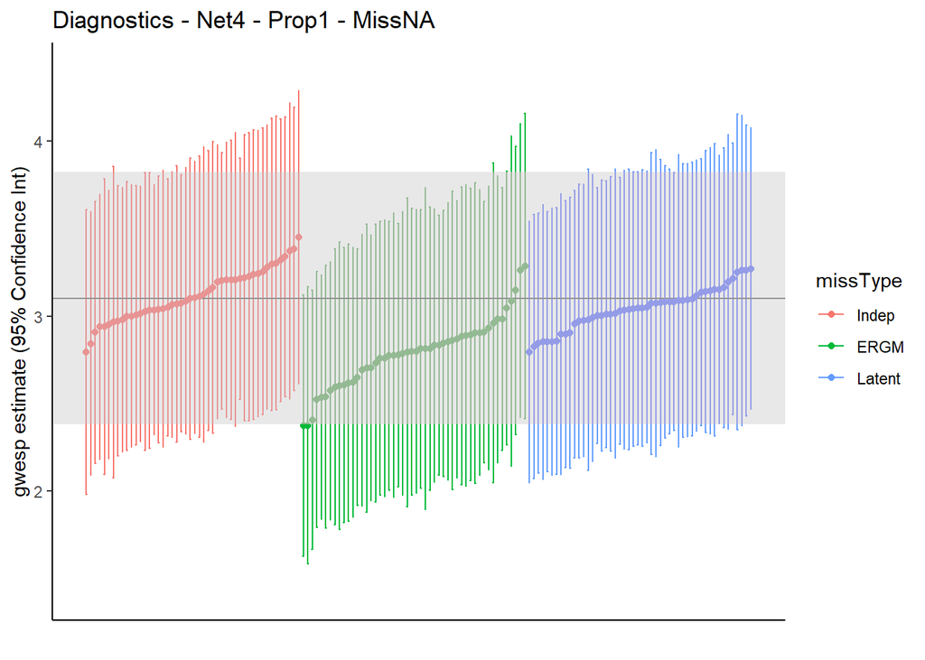

```r
# and see if the plot here matches the one above
missCaterpillarPlot(plotData = testPlotData,
                    truePara = tempTruePara,
                    trueSe = tempTrueSe,
                    chosenPara = "gwesp",
                    chosenNetInd = chosenNetInd,
                    chosenProp = 1,
                    chosenMiss = "NA")
```

```r
# applying the code above to different reestimations
# set a specific index for the network
chosenNetInd = 5

# file list for the chosen network index
chosenNetOutFiles = grep(paste("net", chosenNetInd, sep =""), outputList)

# loop to load
chosenNetOutList = outputList[chosenNetOutFiles]

for(fileInd in 1:length(chosenNetOutList)){
  # load all files
  load(here("Output", "20230814_simMissNets", chosenNetOutList[fileInd]))

  # suppress these version difference warnings.
  suppressWarnings({
  modelResList[[fileInd]] = modelres$coefficients
  modelSeList[[fileInd]] = summary(modelres)$coefficients[,2]

  })

  # regex to get the first number after the specified text
  missModelList[[fileInd]] = as.integer(sub(".*?_missModel.*?(\\d+).*", "\\1", chosenNetOutList[[fileInd]]))
  propMissList[[fileInd]] = as.integer(sub(".*?_prop.*?(\\d+).*", "\\1", chosenNetOutList[[fileInd]]))

}

# first try with alt star
chosenPara = 2

tempTruePara = trueCoefList[[chosenNetInd]][chosenPara]
tempTrueSe = trueSeList[[chosenNetInd]][chosenPara]


# test run of the plot function
testPlotData = prepMissPlot(modelResList = modelResList,
                            modelSeList = modelSeList,
                            missModelList = missModelList,
                            propMissList = propMissList,
                            chosenProp = 1,
                            chosenPara = "altStar")

head(testPlotData)
```

```
##     parameter        SE missModel
## 14 -0.4271309 0.2344825     Indep
## 1  -0.3689833 0.2283937     Indep
## 9  -0.3686057 0.2258536     Indep
## 2  -0.3471691 0.2368848     Indep
## 17 -0.3043420 0.2638864     Indep
## 16 -0.2999977 0.2291898     Indep
```

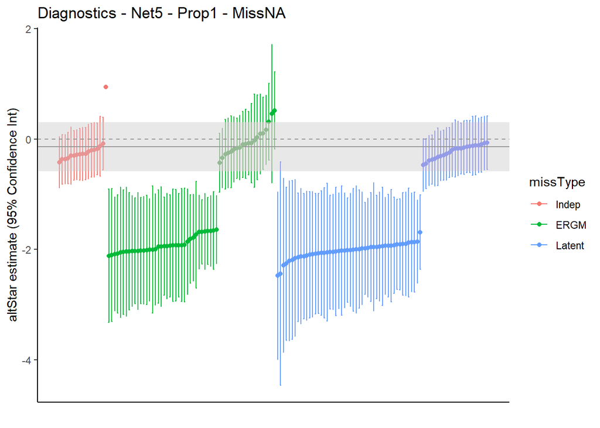

```r
# and see if the plot here matches the one above
missCaterpillarPlot(plotData = testPlotData,
                    truePara = tempTruePara,
                    trueSe = tempTrueSe,
                    chosenPara = "altStar",
                    chosenNetInd = chosenNetInd,
                    chosenProp = 1,
                    chosenMiss = "NA")
```

```r
# still need to take out true parameter values
chosenPara = 3

tempTruePara = trueCoefList[[chosenNetInd]][chosenPara]
tempTrueSe = trueSeList[[chosenNetInd]][chosenPara]


# test run of the plot function
testPlotData = prepMissPlot(modelResList = modelResList,
                            modelSeList = modelSeList,
                            missModelList = missModelList,
                            propMissList = propMissList,
                            chosenProp = 1,
                            chosenPara = "gwesp")

head(testPlotData)
```

```
##    parameter        SE missModel
## 13 0.5529485        NA     Indep
## 15 1.3536200 0.3463476     Indep
## 4  1.4155391 0.3970444     Indep
## 10 1.5321071 0.3904505     Indep
## 3  1.5354860 0.3464884     Indep
## 11 1.5899620 0.3939409     Indep
```

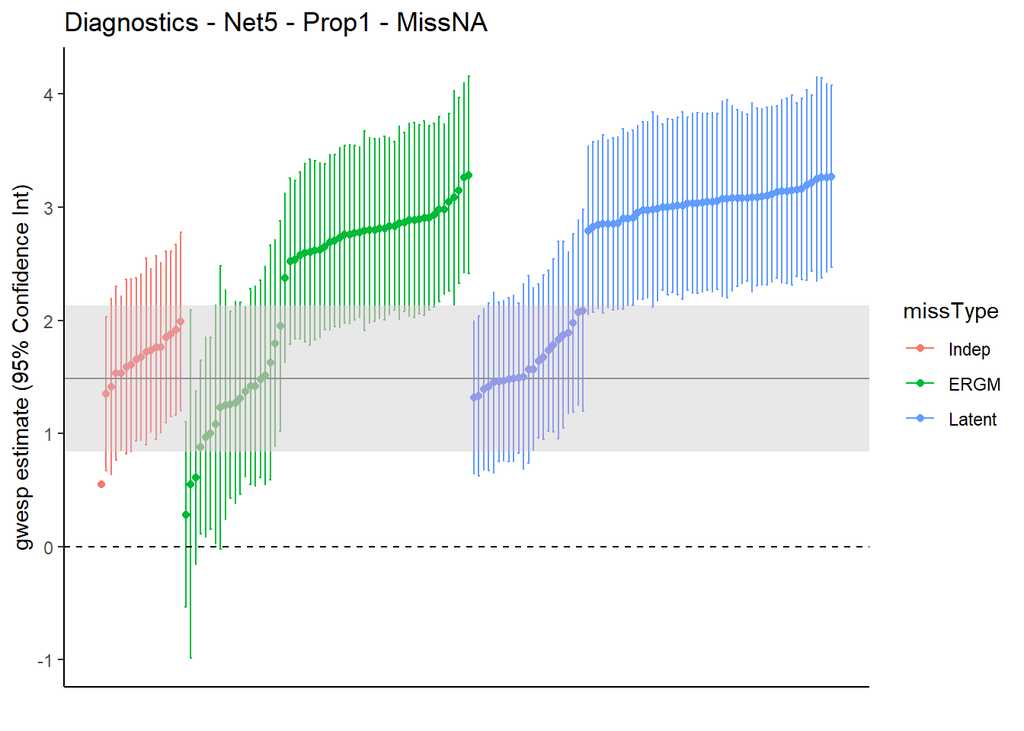

```r
# and see if the plot here matches the one above
missCaterpillarPlot(plotData = testPlotData,
                    truePara = tempTruePara,
                    trueSe = tempTrueSe,
                    chosenPara = "gwesp",
                    chosenNetInd = chosenNetInd,
                    chosenProp = 1,
                    chosenMiss = "NA")
```

```r
# applying the code above to different reestimations
# set a specific index for the network
chosenNetInd = 6

# file list for the chosen network index
chosenNetOutFiles = grep(paste("net", chosenNetInd, sep =""), outputList)

# loop to load
chosenNetOutList = outputList[chosenNetOutFiles]

for(fileInd in 1:length(chosenNetOutList)){
  # load all files
  load(here("Output", "20230814_simMissNets", chosenNetOutList[fileInd]))

  # suppress these version difference warnings.
  suppressWarnings({
  modelResList[[fileInd]] = modelres$coefficients
  modelSeList[[fileInd]] = summary(modelres)$coefficients[,2]

  })

  # regex to get the first number after the specified text
  missModelList[[fileInd]] = as.integer(sub(".*?_missModel.*?(\\d+).*", "\\1", chosenNetOutList[[fileInd]]))
  propMissList[[fileInd]] = as.integer(sub(".*?_prop.*?(\\d+).*", "\\1", chosenNetOutList[[fileInd]]))

}

# first try with alt star
chosenPara = 2

tempTruePara = trueCoefList[[chosenNetInd]][chosenPara]
tempTrueSe = trueSeList[[chosenNetInd]][chosenPara]


# test run of the plot function
testPlotData = prepMissPlot(modelResList = modelResList,
                            modelSeList = modelSeList,
                            missModelList = missModelList,
                            propMissList = propMissList,
                            chosenProp = 1,
                            chosenPara = "altStar")

head(testPlotData)
```

```
##    parameter        SE missModel
## 19 0.8731739 0.5084740     Indep
## 48 0.8741452 0.5042787     Indep
## 47 0.9169817 0.5029527     Indep
## 41 0.9633755 0.4894958     Indep
## 20 0.9943687 0.5330920     Indep
## 15 0.9954447 0.5469702     Indep
```

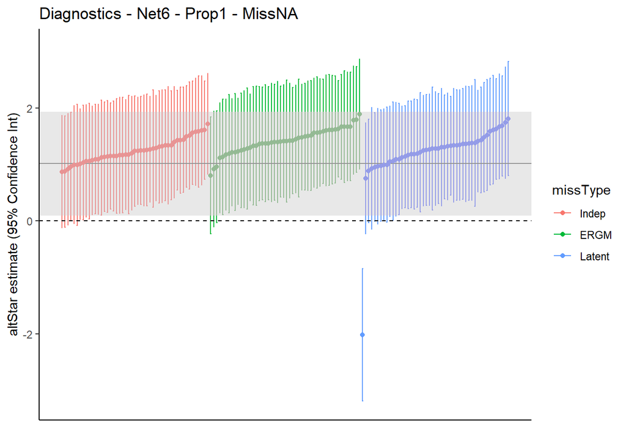

```r
# and see if the plot here matches the one above
missCaterpillarPlot(plotData = testPlotData,
                    truePara = tempTruePara,
                    trueSe = tempTrueSe,
                    chosenPara = "altStar",
                    chosenNetInd = chosenNetInd,
                    chosenProp = 1,
                    chosenMiss = "NA")
```

```r
# still need to take out true parameter values
chosenPara = 3

tempTruePara = trueCoefList[[chosenNetInd]][chosenPara]
tempTrueSe = trueSeList[[chosenNetInd]][chosenPara]


# test run of the plot function
testPlotData = prepMissPlot(modelResList = modelResList,
                            modelSeList = modelSeList,
                            missModelList = missModelList,
                            propMissList = propMissList,
                            chosenProp = 1,
                            chosenPara = "gwesp")

head(testPlotData)
```

```
##    parameter        SE missModel
## 20  1.167036 0.2069259     Indep
## 36  1.170030 0.1937431     Indep
## 15  1.182394 0.2094213     Indep
## 48  1.215846 0.2024918     Indep
## 19  1.239609 0.2300999     Indep
## 35  1.247475 0.1934139     Indep
```

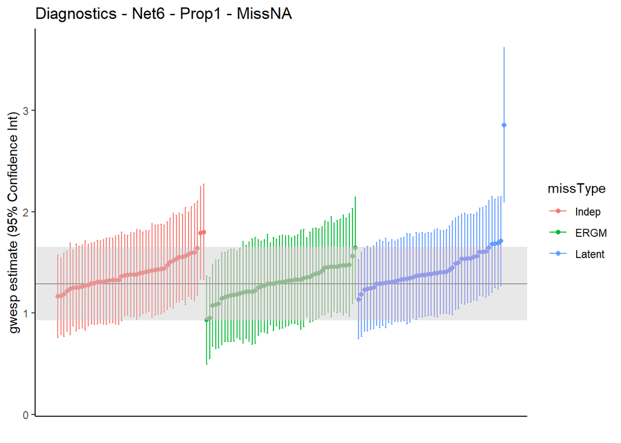

```r
# and see if the plot here matches the one above
missCaterpillarPlot(plotData = testPlotData,
                    truePara = tempTruePara,
                    trueSe = tempTrueSe,
                    chosenPara = "gwesp",
                    chosenNetInd = chosenNetInd,
                    chosenProp = 1,
                    chosenMiss = "NA")
```

## Looking into specific metrics with varying parameter values

These plots are meant to be follow-up plots to anything interesting from the caterpillars above. For example, if we see that a specific model of missingness leads to an odd-looking effect on the caterpillar plots (i.e., affect the re-estimations in a systematic way), then we can look into its specific metric changes when we change the missingness model.

This missingness model will be changed in terms of both which parameters are in it and what the parameter values are (e.g., higher or lower gwesp/altstar values). These don’t need to be re-estimations of anything really, these would just be different ways of degrading the ‘full’ network given a specific missingness proportion. From then on, we can then suggest that specific parameter values and specific parameters lead to some effects.

Some of the metrics we can look at include clustering and centralisation and some of the mean value parameterisations obtained from not estimating each parameter (obtainable through summary(model)).

These metrics will not require re-estimations, but should be guided BY the re-estimations because there are a lot of metrics and possible parameter values and specifications.

What will actually be done here is given a depleted network, as guided by the caterpillar plots above, we can first calculate the various metrics the depleted networks have, a ‘benchmark’ from the ‘true’ network, and simulations given the depleted network… right?

```r
# making the metric plots
# needs a couple of packages
# reading some packages
library(sna)
library(ergm)
library(network)

# load the adjacency matrices for the respective datasets used
load(here("Data", "20230814_missNetsAdjMats.RData"))

# choose some network
chosenNetInd = 2
testNet = adjMatList[[chosenNetInd]]

# function to calculate metrics
netMetrics = function(net, directed = FALSE){

  ## netMetrics(net, directed) calculates some metrics for a given network. Needs the 'sna' package
  ## and the 'network' package to work.
  ##
  ## Input:
  ## - net: Ideally a network object for the network whose metrics will be calculated. Technically
  ##        can be an adjacency matrix since it will be converted to a network object.
  ##
  ## - directed: A logical value to indicate whether the network is directed or not.
  ##
  ## Output:
  ## - The output is a list of different network metrics. These include the clustering coefficient,
  ##   the global centralisation (degree variance) value, the median geodesic distance, and median
  ##   betweenness centrality. More metrics can be added on as necessary.

  # needs two packages
  require(network)
  require(sna)

  # specify if undirected or not
  mode = 'graph'

  # if instead directed network are the input, turn it directed
  if(directed == TRUE){
    mode = 'digraph'
  }

  # if input is an adjacency matrix, turn it into a network object
  if(inherits(net, "matrix")){
    net = as.network(net, directed = directed)
    print("Matrix coerced to network object")

  }

  # make sure there's no missingness in it
  if(network.naedgecount(net) != 0){

    tempMat = as.matrix(net)
    tempMat[is.na(tempMat)] = 0
    net = as.network(tempMat, directed = directed)
    print("Missing values in the network converted to 0s")

  }



  # getting a distribution of clustering coefficients for the 80 simulated graphs
  tempClust <- gtrans(net, mode = mode)
  tempCent <- centralization(net, degree, mode = mode)
  tempGeodistMedian <- median(geodist(net, inf.replace = NA)$gdist, na.rm = T)
  tempBetwMedian <- median(betweenness(net, gmode = mode))

  ## specify the chosen metric
  metricList = list("clustering" = tempClust,
                    "centralisation" = tempCent,
                    "MedianGeodesic" = tempGeodistMedian,
                    "MedianBetween" = tempBetwMedian)

  # return the list of metrics
  return(metricList)

}


## get mean value parameterisations
# function to check mean value parameterisations
meanValPar = function(net, model){

  ## net is the outcome network, usually the degraded adjacency matrix
  ## model is a STRING for the specified model

  # paste together the input network object and the specified model
  eval(parse(text = paste("chosenModel = net", "~", model )))

  # check mean value par
  summary(chosenModel)
}


## before defining the function, let's make sure it works first of all
# this is todd-only functionality because simulating with NAs doesn't seem particularly informative
# the idea here is given some specific model-based missingness (or sampling), what are the effects of different parameters



# function to generate simulated networks
trueNet = as.network(testNet, directed = FALSE)

# read in some of the simulated missingness
load(here("Output", "20230814_simMissNets", "20230825_simMissErgmNets_ergmCoef_3_propMiss1.RData"))

initMissNet = missErgmSimNets[[1]][[1]]

# to save computation time, the outcome 'network' (missngness matrix) does not need to be read in, I just need
# a specific proportion for the density

# read in the functions I made before
source(here("Scripts", "20230811_missNetFunctions.R"))

# and then initialise a matrix with a fixed density
initMissNet2 = initMissAdj(n = network.size(trueNet),
                           propMiss = 0.1)  # second argument will be changed depending on the propMiss

# set the initial network
net = as.network(initMissNet2, directed = FALSE)

# from then on, simulate multiple possible Ds
# specify some arguments
paraRange = seq(from = -2, to = 2, length.out = 50)
modelSpec = net ~ edges +
                          gwdegree(0.69, fixed = TRUE) +
                          gwesp(0.69, fixed = TRUE) +
                          dyadcov(trueNet) +
                          nodecov('degree')

# some random initial parameters (0 is for edges)
initParas = c(0, 0.5, -0.2, 0.3, 0.8)

# integer to choose which parameter's getting changed
chosenPara = 2


 # degree covariate calculation, should I retroactively update the reestimation code to attach the degree covariate...
  # might be better to specify the true network here...
  net %v% 'degree' = rowSums(as.matrix(trueNet))

  # initialising the simulation
  netStart = net
  simNetList = list()

  # loop to simulate different gwdeg values
  for (paraIndex in c(1:length(paraRange)) ){

   # a conditional after the first loop for making the starting network iterate between gwdeg parameters
    if ( paraIndex > 1 ){
    netStart <- tempSimNets[[1]]
       netStart %v% 'degree' = rowSums(as.matrix(trueNet))
    }

    # choose coefs
    chosenCoefs = initParas
    chosenCoefs[chosenPara] = paraRange[paraIndex]

    # simulating 80 networks given the specified model and their parameter values
    tempSimNets <- simulate(object = modelSpec,
                            constraints =~edges,
                            coef= chosenCoefs,
                            control=control.simulate(
                              MCMC.burnin=20000,
                              MCMC.interval=100), nsim=80 )

    # save the simulated networks
    simNetList[[paraIndex]] = tempSimNets

  }

# then deplete the true network with the simulated missingness matrices
trueMat = as.matrix(trueNet)

# turn everything into matrices
simMissAdjList = lapply(simNetList, function(x){lapply(x, as.matrix)})

# with the list of missingness matrices, apply them to the true adjmat to deplete
# usingt he degrade adj function as a small shortcut
# a doozy of code line, but mostly due to the nested-list structure
# saving as Todd because we're calculating metrics
degradedAdjList = lapply(simMissAdjList, function(chosenPara){
  lapply(chosenPara, function(chosenMissAdj){
    degradeAdj(trueNet = trueMat, missAdj = chosenMissAdj, missSave = 0)})})

# turn all of them into networks
# and then calculate the metrics
degradedNetList = lapply(degradedAdjList, function(chosenPara){
  lapply(chosenPara, as.network, directed = FALSE)
})

# then calculate metrics
degradedNetMetrics = lapply(degradedNetList, function(chosenPara){
  lapply(chosenPara, netMetrics)})

# this list can then be used to plot stuff

geneSimNets = function(net, modelSpec, initParas, chosenPara, paraRange, trueNet){

  # takes a network, like a depleted network without missingness (i.e., saved as 0)
  # use different models to simulate networks with the same amount of edges
    # i.e., simulating the effects of various parameter values (and model specification)
    # on a depleted network with constrained edges/density
  # ideally accommodates a range of different model specifications and parameter values
  # the parameters are varied one at a time to view its effect holding constant on other parameters....
  # so the function will look like
  # simNet(toddNet, modelSpec, initParas, chosenPara, paraRange, trueNet)
  # output = list of simulated networks,
  # mean value parameterisations can be applied in a separate chunk of code for the list
  # of simulated networks since it'd be conditional to the model specified for the simulated networks.

  ### NO:
  # take a simulated missingness matrix with a fixed proportion
  # specify some model, with varying specification or parameter values,
  # then simulate some other possible missingness matrices
  # while constraining the edges (fixed prportion of missingness)
  # use the simulated missingness matrices to deplete true adjmat X
  # then calculate metrics and mean value parameterisations on the depleted network

  ## checks
  # make sure it's a network object
  if(inherits(net, "matrix")){
    net = as.network(net)
  }

  # make sure there's no missingness in it
  if(network.naedgecount(testNet) != 0){
    stop("Network has missing values in it.")
  }

  # degree covariate calculation, should I retroactively update the reestimation code to attach the degree covariate...
  # might be better to specify the true network here...
  net %v% 'degree' = rowSums(trueNet)

  # initialising the simulation
  netStart = net
  simNetList = list()

  # loop to simulate different gwdeg values
  for (paraIndex in c(1:length(paraRange)) ){

   # a conditional after the first loop for making the starting network iterate between gwdeg parameters
    if ( paraIndex > 1 ){
    netStart <- tempSimNets[[1]]
       netStart %v% 'degree' = rowSums(trueNet)
    }

    # choose coefs
    chosenCoefs = initParas
    chosenCoefs[chosenPara] = paraRange[paraIndex]

    # simulating 80 networks given the specified model and their parameter values
    tempSimNets <- simulate(object = modelSpec,
                            constraints =~edges,
                            coef= chosenCoefs,
                            control=control.simulate(
                              MCMC.burnin=20000,
                              MCMC.interval=100), nsim=80 )

    # save the simulated networks
    simNetList[[paraIndex]] = tempSimNets

  }
  # return the simulated 'networks' (these are simulated missingness matrices saved as networks)
  return(simNetList)

}

# mean value parameterisation extraction... does this need to be a function?
# could just be a line of code... probably...
```

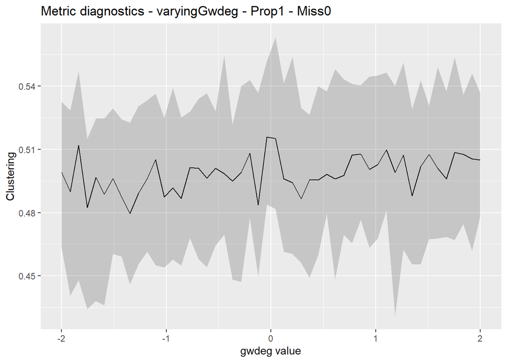

```r
# plotting the degraded metrics with the 'true' value
# and indexing which coefficients are used
# ... and what type of missingness it is...
# ... with indices for what network dataset and the proportion of missingness....

# initial code for making the plot data, turned into a function
# # extracting specific metrics
# uniqueMetrics = unique(names(unlist(degradedNetMetrics[[1]])))
#
# # initialise plot data
# metricPlotData = data.frame(metricName = NA, varyingParameter = NA, parameterValue = NA, quant0.05 = NA, median = NA, quant0.95 = NA)
#
# # additional list for metric ranges
# rawMetricList = list()
#
# # loop to choose different metrics in calculating the different quantiles
# for(chosenMetric in 1:length(uniqueMetrics)){
#
#   # a value for the row index based on the iteration of the loop
#   tempRowInd = seq(from = 1 + (length(degradedNetMetrics) * (chosenMetric - 1)), to = chosenMetric * length(degradedNetMetrics))
#
#   # fix this value for now, but this would depend on the model spec and which chosen para it is
#   chosenParaLabel = "gwdeg"
#   metricPlotData[tempRowInd,"varyingParameter"] = chosenParaLabel
#
#   # put in the metric name
#   metricPlotData[tempRowInd, "metricName"] = uniqueMetrics[chosenMetric]
#
#   # extract the chosen metrics from the nested list
#   rawMetricList[[chosenMetric]] = lapply(degradedNetMetrics, function(chosenParaVal){unlist(chosenParaVal)[names(unlist(chosenParaVal)) == uniqueMetrics[[chosenMetric]]]})
#
#   # fill in the quantiles
#   metricPlotData[tempRowInd, c("quant0.05", "median", "quant0.95")] = do.call(rbind, lapply(rawMetricList[[chosenMetric]], function(chosenParaVal){quantile(chosenParaVal, c(0.05, 0.5, 0.95))}))
#
#   # lastly, give the parameter values
#   metricPlotData[tempRowInd, "parameterValue"] = paraRange
# }

## Function to prep metric plot data
prepMetricPlot = function(degradedNetMetricList, chosenPara){

  ## prepMetricPlot(degradedNetMetricList, chosenPara) takes a list of metric calculated from degraded networks
  ## and a specified parameter name that controlled the degradation to subset them into a data frame to be used
  ## for plotting purposes.
  ##
  ## Input:
  ## - degradedNetMetricList: A list of (nested) network metrics calculated using the netMetrics function on
  ##                          a list of degraded networks. Missingness needs to be saved as 0 for values to calculable.
  ##
  ## - chosenPara: A string to describe which parameter is being varied in the degradation of the networks.
  ##
  ## Output:
  ## - A dataframe containing the metric names, which parameter is being varied and what its value is for the degradation,
  ##   and three quantiles (5, 50, and 95) to describe the range and median of the degraded metric.


  # extracting specific metrics
  uniqueMetrics = unique(names(unlist(degradedNetMetricList[[1]])))

  # initialise plot data
  metricPlotData = data.frame(metricName = NA, varyingParameter = NA, parameterValue = NA, quant0.05 = NA, median = NA, quant0.95 = NA)

  # additional list for metric ranges
  rawMetricList = list()

  # loop to choose different metrics in calculating the different quantiles
  for(chosenMetric in 1:length(uniqueMetrics)){

    # a value for the row index based on the iteration of the loop
    tempRowInd = seq(from = 1 + (length(degradedNetMetricList) * (chosenMetric - 1)), to = chosenMetric * length(degradedNetMetricList))

    # fix this value for now, but this would depend on the model spec and which chosen para it is
    chosenParaLabel = chosenPara
    metricPlotData[tempRowInd,"varyingParameter"] = chosenParaLabel

    # put in the metric name
    metricPlotData[tempRowInd, "metricName"] = uniqueMetrics[chosenMetric]

    # extract the chosen metrics from the nested list
    rawMetricList[[chosenMetric]] = lapply(degradedNetMetricList, function(chosenParaVal){unlist(chosenParaVal)[names(unlist(chosenParaVal)) == uniqueMetrics[[chosenMetric]]]})

    # fill in the quantiles
    metricPlotData[tempRowInd, c("quant0.05", "median", "quant0.95")] = do.call(rbind, lapply(rawMetricList[[chosenMetric]], function(chosenParaVal){quantile(chosenParaVal, c(0.05, 0.5, 0.95))}))

    # lastly, give the parameter values
    metricPlotData[tempRowInd, "parameterValue"] = paraRange
  }

  # return the plot data
  return(metricPlotData)
}

metricPlotData = prepMetricPlot(degradedNetMetricList = degradedNetMetrics, chosenPara = "gwdeg")

# unqiue metric names
uniqueMetrics = unique(names(unlist(degradedNetMetrics[[1]])))

## now that the data's right, it's just a matter of plotting-
metricPlotData %>%
  filter(metricName == "clustering") %>%
  ggplot(aes(x = parameterValue, y = median)) +
  geom_line() +
  geom_ribbon(aes(ymin = quant0.05, ymax = quant0.95), alpha = 0.2) +
  labs(title = "Metric diagnostics - varyingGwdeg - Prop1 - Miss0") +
  xlab("gwdeg value") +
  ylab("Clustering")
```

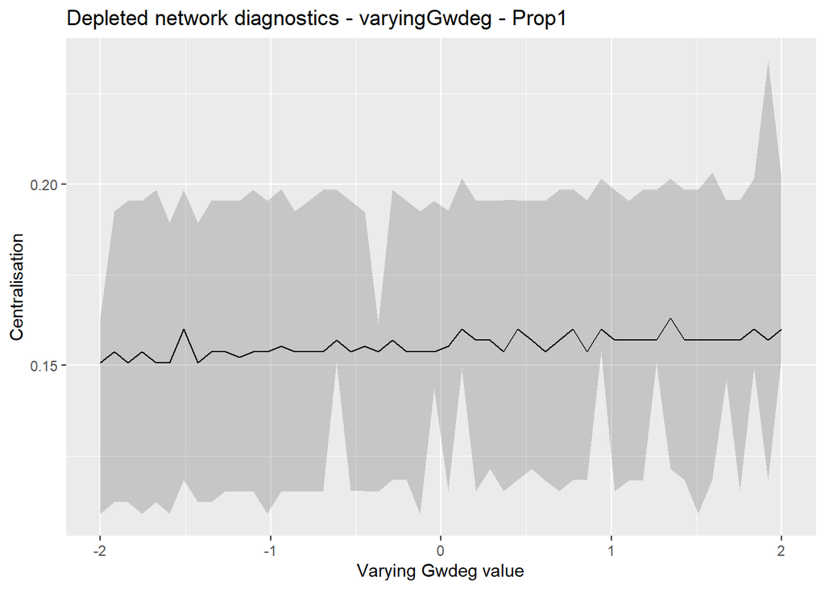

```r
# note: the chosen missingness will always be 0 because calculating metrics needs missingness to be 0, so take it off the plot title

## Turn this base plot code into a function-
missMetricPlot = function(data, chosenMetric, chosenPara, chosenProp){

  ## missMetricPlot(data, chosenMetric, chosenPara, chosenProp) is a very specialised plotting function that
  ## produces a caterpillar plot to compare parameter estimates for very specific data.
  ##
  ## Input:
  ## - data: A data frame containing the metric name, varying parameter, the varying parameter's value, and
  ##         5th, 50th, and 95th quantiles of the metric. Obtained from prepMetricPlot().
  ##
  ## - chosenPara: A string to describe which parameter is being varied in the degradation of the networks.
  ##
  ## - chosenProp: A single integer or float with three options representing the proportion of missingness.
  ##               Options are 1 = 10%, 3.5 = 35%, 6 = 60%.
  ##
  ## Output:
  ## - The output should be a line plot with a shaded area representing the 90% confidence interval of the metric.
  ##   Its labels should be adaptive to the chosen metric, (varying) parameter, and proportion of missingness.


  # requires ggplot2 and dplyr
  require(ggplot2)
  require(dplyr)

  # and plot
  data %>%
  filter(metricName == chosenMetric) %>%
  ggplot(aes(x = parameterValue, y = median)) +
  geom_line() +
  geom_ribbon(aes(ymin = quant0.05, ymax = quant0.95), alpha = 0.2) +
  labs(title = paste("Depleted network diagnostics - varying", chosenPara," - Prop", chosenProp, sep = "")) +
  xlab(paste("Varying", chosenPara, "value")) +
  ylab(paste(toupper(substr(chosenMetric, 1, 1)), substr(chosenMetric, 2, nchar(chosenMetric)), sep = ""))

}


# do this for all the unique metrics
missMetricPlot(data = metricPlotData, chosenMetric = uniqueMetrics[2], chosenPara = "Gwdeg", chosenProp = 1)
```

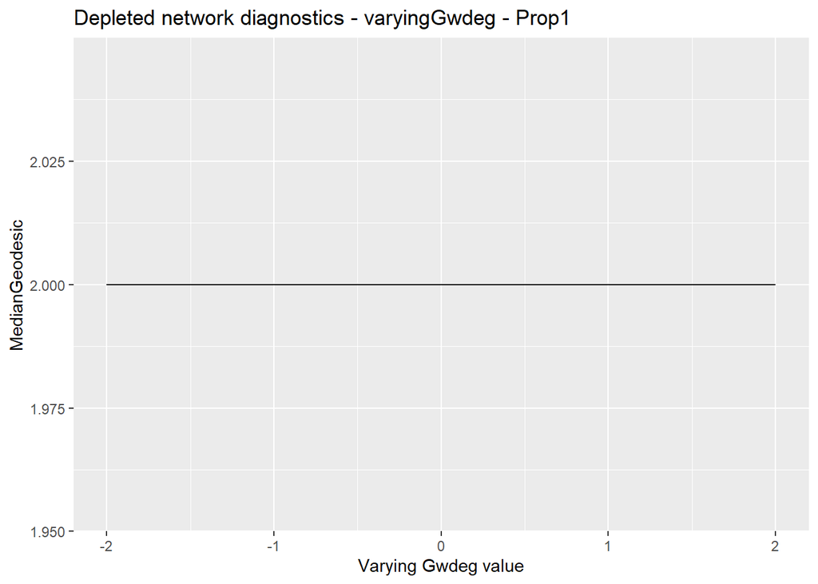

```r
missMetricPlot(data = metricPlotData, chosenMetric = uniqueMetrics[3], chosenPara = "Gwdeg", chosenProp = 1)
```

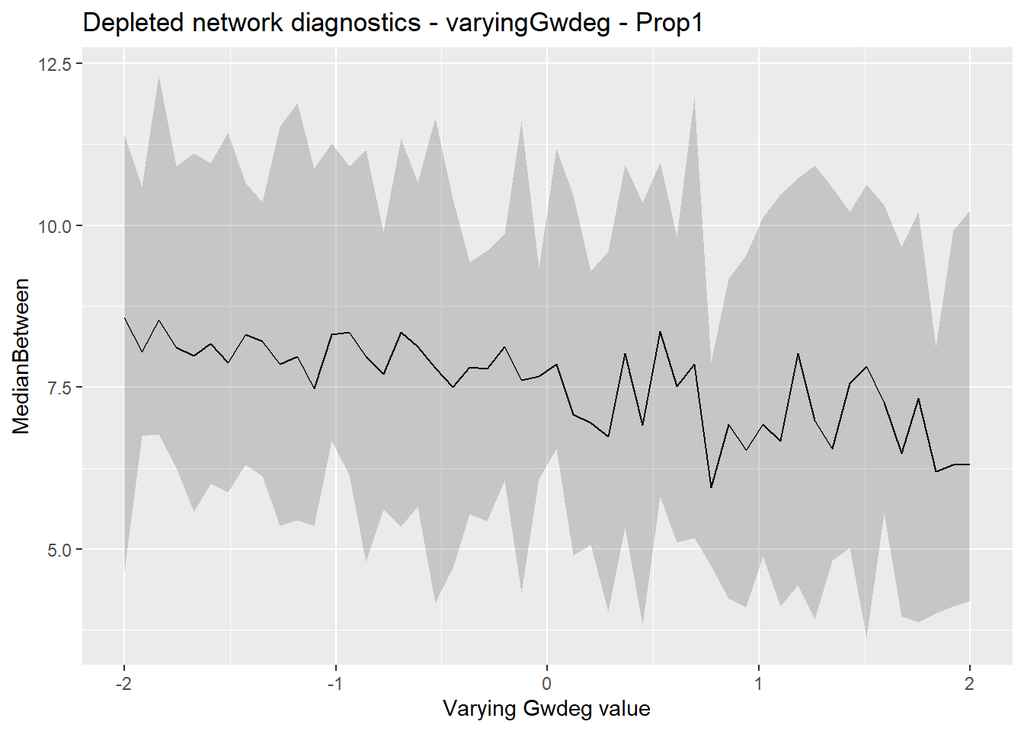

```r
missMetricPlot(data = metricPlotData, chosenMetric = uniqueMetrics[4], chosenPara = "Gwdeg", chosenProp = 1)
```

```r
### and now the mean value parameterisations
# a check to make sure it works
meanValPar(net = degradedNetList[[4]][[10]],
           model = "edges + gwdegree(decay = log(2), fixed = TRUE) + gwesp(decay = log(2), fixed = TRUE)")
```

```
##                         edges gwdeg.fixed.0.693147180559945
##                      84.00000                      51.98242
## gwesp.fixed.0.693147180559945
##                     127.78125
```

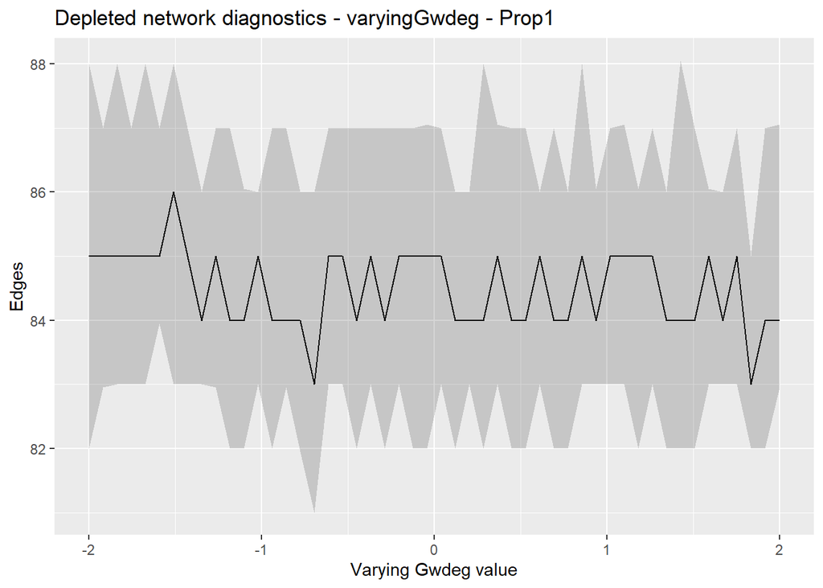

```r
# mass apply to lists
meanValParLists = lapply(degradedNetList, function(chosenParaVal){
  lapply(chosenParaVal, meanValPar, model = "edges + gwdegree(decay = log(2), fixed = TRUE) + gwesp(decay = log(2), fixed = TRUE)")
})

# unlist them to plot
meanValParUnlisted = lapply(meanValParLists, unlist)

### commented out section is for code that is largely identical to the function to prep plot data above
# # initialise plot data
# meanValPlotData = data.frame(parameterName = NA, varyingParameter = NA, parameterValue = NA, quant0.05 = NA, median = NA, quant0.95 = NA)
#
# # additional list for metric ranges
# rawMeanValList = list()
#
# # grab unique parameter names
# uniqueParaNames = unique(names(meanValParUnlisted[[1]]))
#
# # loop to grab the quantiles of each of these mean value parameterisation values for each parameter
# for(chosenParaName in 1:length(uniqueParaNames)){
#
#   # a value for the row index based on the iteration of the loop
#   tempRowInd = seq(from = 1 + (length(meanValParUnlisted) * (chosenParaName - 1)), to = chosenParaName * length(meanValParUnlisted))
#
#   # fix this value for now, but this would depend on the model spec and which chosen para it is
#   chosenParaLabel = "gwdeg"
#   meanValPlotData[tempRowInd,"varyingParameter"] = chosenParaLabel
#
#   # put in the metric name
#   meanValPlotData[tempRowInd, "parameterName"] = uniqueParaNames[chosenParaName]
#
#   # extract the chosen metrics from the nested list
#   rawMeanValList[[chosenParaName]] = lapply(meanValParLists, function(chosenParaVal){unlist(chosenParaVal)[names(unlist(chosenParaVal)) == uniqueParaNames[[chosenParaName]]]})
#
#   # fill in the quantiles
#   meanValPlotData[tempRowInd, c("quant0.05", "median", "quant0.95")] = do.call(rbind, lapply(rawMeanValList[[chosenParaName]], function(chosenParaVal){quantile(chosenParaVal, c(0.05, 0.5, 0.95))}))
#
#   # lastly, give the parameter values
#   meanValPlotData[tempRowInd, "parameterValue"] = paraRange
# }

## if I consider the mean value parametrisations as another metric, I don't need another chunk of code specifically for these
meanValPlotData = prepMetricPlot(degradedNetMetricList = meanValParUnlisted, chosenPara = "gwdeg")

# check all unique parameter names
uniqueParaNames = unique(names(meanValParUnlisted[[1]]))

# and check to make sure the plots work
missMetricPlot(data = meanValPlotData, chosenMetric = uniqueParaNames[1], chosenPara = "Gwdeg", chosenProp = 1)
```

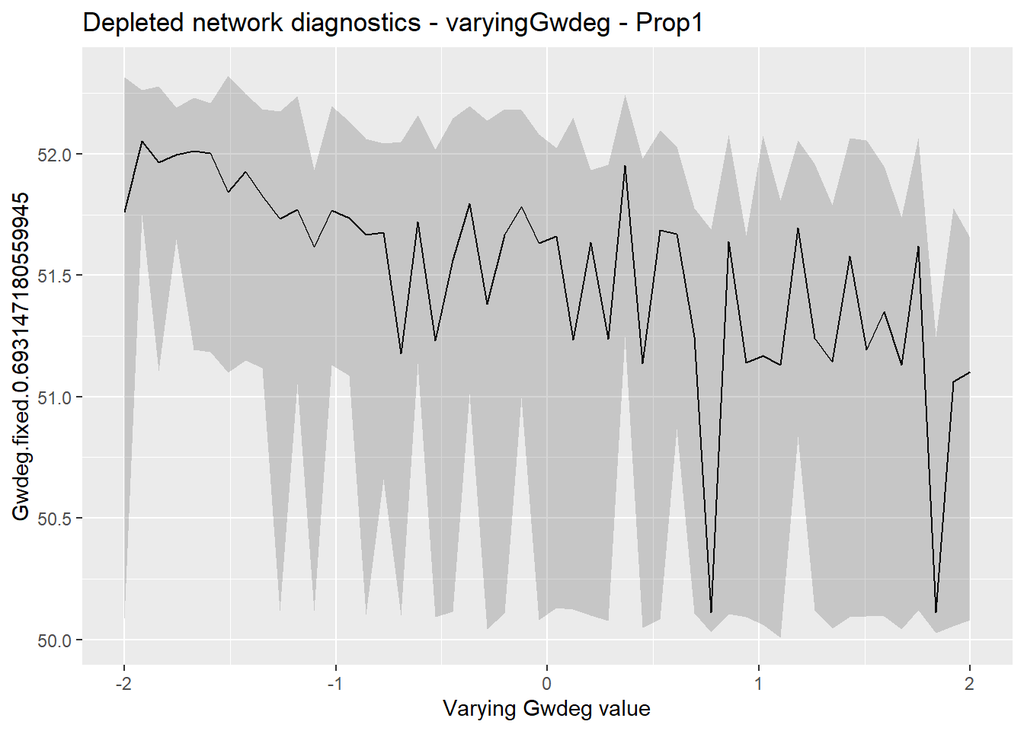

```r
missMetricPlot(data = meanValPlotData, chosenMetric = uniqueParaNames[2], chosenPara = "Gwdeg", chosenProp = 1)
```

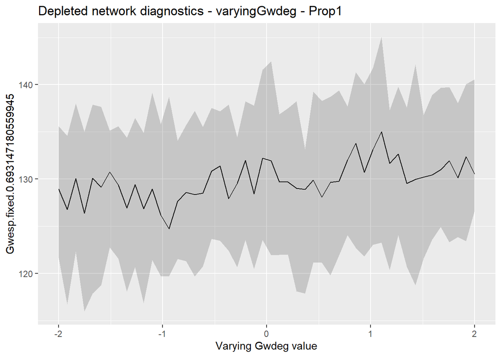

```r
missMetricPlot(data = meanValPlotData, chosenMetric = uniqueParaNames[3], chosenPara = "Gwdeg", chosenProp = 1)
```

## More plots for more missingness proportions

### 10% missingness - Todd

```r
# loading in the output results
outputList = list.files(here("Output", "20230825_simMissReest", "Todd"))

# set up some lists to put in the ergm re-estimations
modelResList = list()
modelSeList = list()
missModelList = list()
propMissList = list()

# set a specific index for the network
chosenNetInd = 1

# file list for the chosen network index, change whenever necessary
chosenNetOutFiles = grep(paste("20231005_missNetReest_net", chosenNetInd, sep =""), outputList)

# loop to load
chosenNetOutList = outputList[chosenNetOutFiles]

for(fileInd in 1:length(chosenNetOutList)){
  # load all files
  load(here("Output", "20230825_simMissReest", "Todd", chosenNetOutList[fileInd]))

  # suppress these version difference warnings.
  suppressWarnings({
  modelResList[[fileInd]] = modelres$coefficients
  modelSeList[[fileInd]] = summary(modelres)$coefficients[,2]

  })

  # regex to get the first number after the specified text
  missModelList[[fileInd]] = as.integer(sub(".*?_missModel.*?(\\d+).*", "\\1", chosenNetOutList[[fileInd]]))
  propMissList[[fileInd]] = as.integer(sub(".*?_prop.*?(\\d+).*", "\\1", chosenNetOutList[[fileInd]]))
}

# first try with alt star
chosenPara = 2

tempTruePara = trueCoefList[[chosenNetInd]][chosenPara]
tempTrueSe = trueSeList[[chosenNetInd]][chosenPara]


# test run of the plot function
testPlotData = prepMissPlot(modelResList = modelResList,
                            modelSeList = modelSeList,
                            missModelList = missModelList,
                            propMissList = propMissList,
                            chosenProp = 1,
                            chosenPara = "altStar")

head(testPlotData)
```

```
##    parameter        SE missModel
## 5  -2.209327 0.5979698     Indep
## 23 -2.189741 0.6877216     Indep
## 30 -2.066400 0.5400037     Indep
## 4  -2.026562 0.4440535     Indep
## 13 -1.986430 0.4411822     Indep
## 39 -1.977470 0.4192232     Indep
```

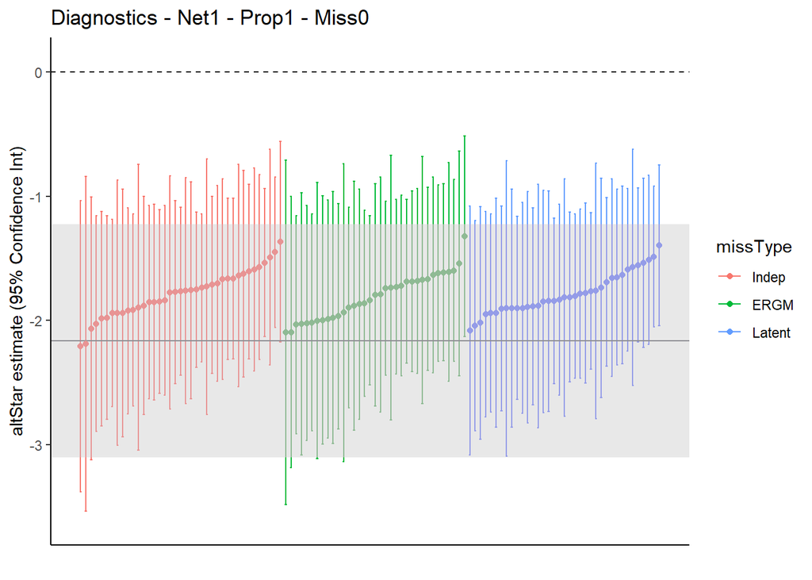

```r
# and see if the plot here matches the one above
missCaterpillarPlot(plotData = testPlotData,
                    truePara = tempTruePara,
                    trueSe = tempTrueSe,
                    chosenPara = "altStar",
                    chosenNetInd = chosenNetInd,
                    chosenProp = 1,
                    chosenMiss = "0")
```

```r
# still need to take out true parameter values
chosenPara = 3

tempTruePara = trueCoefList[[chosenNetInd]][chosenPara]
tempTrueSe = trueSeList[[chosenNetInd]][chosenPara]


# test run of the plot function
testPlotData = prepMissPlot(modelResList = modelResList,
                            modelSeList = modelSeList,
                            missModelList = missModelList,
                            propMissList = propMissList,
                            chosenProp = 1,
                            chosenPara = "gwesp")

head(testPlotData)
```

```
##    parameter        SE missModel
## 2   2.409912 0.2867801     Indep
## 25  2.416764 0.2709456     Indep
## 3   2.762928 0.3026043     Indep
## 31  2.874716 0.3174043     Indep
## 26  2.911591 0.3013970     Indep
## 6   2.946111 0.3113748     Indep
```

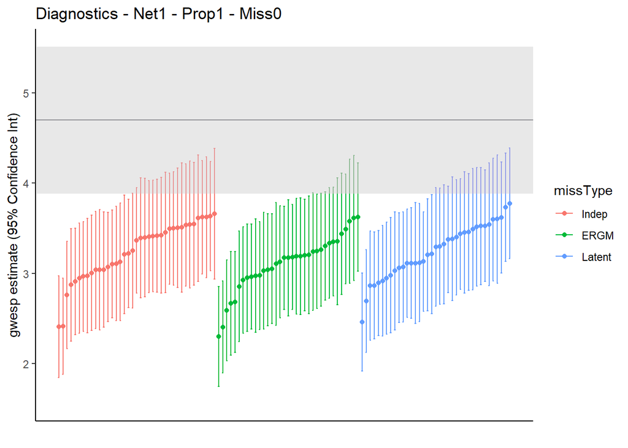

```r
# and see if the plot here matches the one above
missCaterpillarPlot(plotData = testPlotData,
                    truePara = tempTruePara,
                    trueSe = tempTrueSe,
                    chosenPara = "gwesp",
                    chosenNetInd = chosenNetInd,
                    chosenProp = 1,
                    chosenMiss = "0")
```

```r
# set a specific index for the network
chosenNetInd = 2

# file list for the chosen network index, change whenever necessary
chosenNetOutFiles = grep(paste("20231005_missNetReest_net", chosenNetInd, sep =""), outputList)

# loop to load
chosenNetOutList = outputList[chosenNetOutFiles]

for(fileInd in 1:length(chosenNetOutList)){
  # load all files
  load(here("Output", "20230825_simMissReest", "Todd", chosenNetOutList[fileInd]))

  # suppress these version difference warnings.
  suppressWarnings({
  modelResList[[fileInd]] = modelres$coefficients
  modelSeList[[fileInd]] = summary(modelres)$coefficients[,2]

  })

  # regex to get the first number after the specified text
  missModelList[[fileInd]] = as.integer(sub(".*?_missModel.*?(\\d+).*", "\\1", chosenNetOutList[[fileInd]]))
  propMissList[[fileInd]] = as.integer(sub(".*?_prop.*?(\\d+).*", "\\1", chosenNetOutList[[fileInd]]))
}

# first try with alt star
chosenPara = 2

tempTruePara = trueCoefList[[chosenNetInd]][chosenPara]
tempTrueSe = trueSeList[[chosenNetInd]][chosenPara]


# test run of the plot function
testPlotData = prepMissPlot(modelResList = modelResList,
                            modelSeList = modelSeList,
                            missModelList = missModelList,
                            propMissList = propMissList,
                            chosenProp = 1,
                            chosenPara = "altStar")

head(testPlotData)
```

```
##    parameter        SE missModel
## 21 -2.568440 1.1667600     Indep
## 14 -2.378623 0.8922353     Indep
## 36 -2.341166 0.9318989     Indep
## 8  -2.336268 1.1878642     Indep
## 46 -2.330456 0.8169489     Indep
## 48 -2.304476 1.1932852     Indep
```

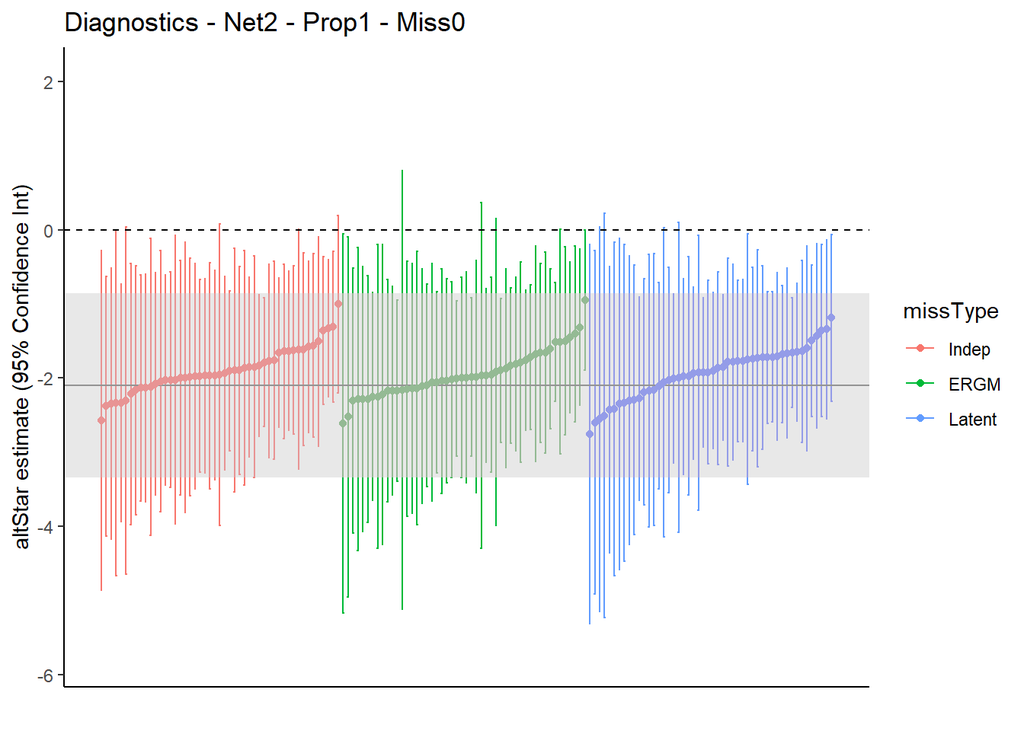

```r
# and see if the plot here matches the one above
missCaterpillarPlot(plotData = testPlotData,
                    truePara = tempTruePara,
                    trueSe = tempTrueSe,
                    chosenPara = "altStar",
                    chosenNetInd = chosenNetInd,
                    chosenProp = 1,
                    chosenMiss = "0")
```

```r
# still need to take out true parameter values
chosenPara = 3

tempTruePara = trueCoefList[[chosenNetInd]][chosenPara]
tempTrueSe = trueSeList[[chosenNetInd]][chosenPara]


# test run of the plot function
testPlotData = prepMissPlot(modelResList = modelResList,
                            modelSeList = modelSeList,
                            missModelList = missModelList,
                            propMissList = propMissList,
                            chosenProp = 1,
                            chosenPara = "gwesp")

head(testPlotData)
```

```
##    parameter        SE missModel
## 5   1.549235 0.3025049     Indep
## 29  1.710355 0.3314923     Indep
## 24  1.878453 0.3544091     Indep
## 44  1.900765 0.3554659     Indep
## 18  2.099150 0.3389286     Indep
## 39  2.122251 0.3851450     Indep
```

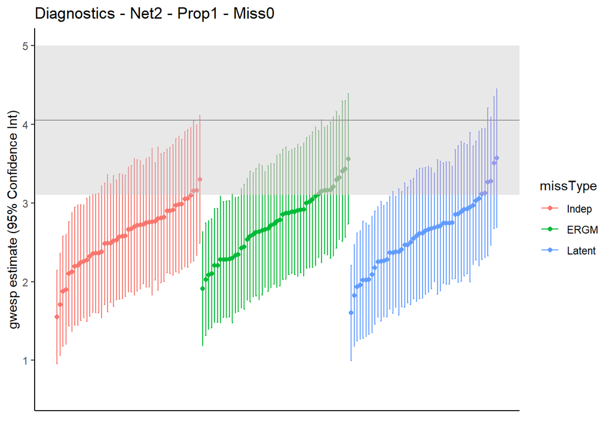

```r
# and see if the plot here matches the one above
missCaterpillarPlot(plotData = testPlotData,
                    truePara = tempTruePara,
                    trueSe = tempTrueSe,
                    chosenPara = "gwesp",
                    chosenNetInd = chosenNetInd,
                    chosenProp = 1,
                    chosenMiss = "0")
```

```r
# set a specific index for the network
chosenNetInd = 4

# file list for the chosen network index, change whenever necessary
chosenNetOutFiles = grep(paste("20231005_missNetReest_net", chosenNetInd, sep =""), outputList)

# loop to load
chosenNetOutList = outputList[chosenNetOutFiles]

for(fileInd in 1:length(chosenNetOutList)){
  # load all files
  load(here("Output", "20230825_simMissReest", "Todd", chosenNetOutList[fileInd]))

  # suppress these version difference warnings.
  suppressWarnings({
  modelResList[[fileInd]] = modelres$coefficients
  modelSeList[[fileInd]] = summary(modelres)$coefficients[,2]

  })

  # regex to get the first number after the specified text
  missModelList[[fileInd]] = as.integer(sub(".*?_missModel.*?(\\d+).*", "\\1", chosenNetOutList[[fileInd]]))
  propMissList[[fileInd]] = as.integer(sub(".*?_prop.*?(\\d+).*", "\\1", chosenNetOutList[[fileInd]]))
}

# first try with alt star
chosenPara = 2

tempTruePara = trueCoefList[[chosenNetInd]][chosenPara]
tempTrueSe = trueSeList[[chosenNetInd]][chosenPara]


# test run of the plot function
testPlotData = prepMissPlot(modelResList = modelResList,
                            modelSeList = modelSeList,
                            missModelList = missModelList,
                            propMissList = propMissList,
                            chosenProp = 1,
                            chosenPara = "altStar")

head(testPlotData)
```

```
##    parameter        SE missModel
## 34 -2.003352 0.6859301     Indep
## 26 -1.947103 0.6863618     Indep
## 44 -1.940004 0.6037775     Indep
## 38 -1.911503 0.5101568     Indep
## 30 -1.903417 0.4739233     Indep
## 6  -1.901365 0.7485541     Indep
```

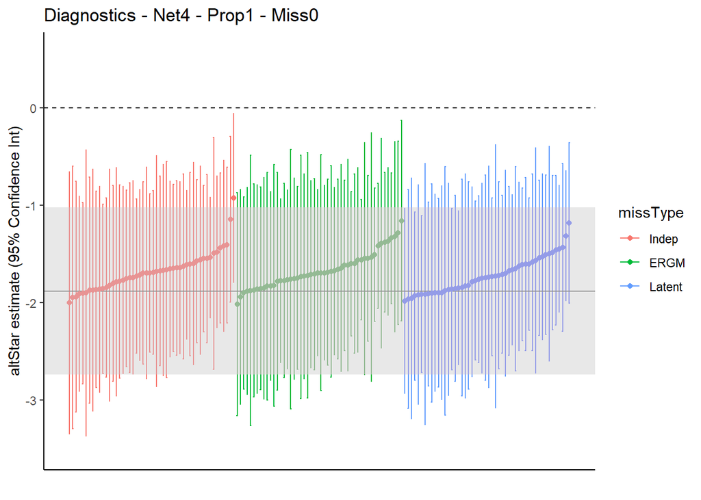

```r
# and see if the plot here matches the one above
missCaterpillarPlot(plotData = testPlotData,
                    truePara = tempTruePara,
                    trueSe = tempTrueSe,
                    chosenPara = "altStar",
                    chosenNetInd = chosenNetInd,
                    chosenProp = 1,
                    chosenMiss = "0")
```

```r
# still need to take out true parameter values
chosenPara = 3

tempTruePara = trueCoefList[[chosenNetInd]][chosenPara]
tempTrueSe = trueSeList[[chosenNetInd]][chosenPara]


# test run of the plot function
testPlotData = prepMissPlot(modelResList = modelResList,
                            modelSeList = modelSeList,
                            missModelList = missModelList,
                            propMissList = propMissList,
                            chosenProp = 1,
                            chosenPara = "gwesp")

head(testPlotData)
```

```
##    parameter        SE missModel
## 48  1.591746 0.3083361     Indep
## 4   1.612123 0.2829673     Indep
## 18  1.694798 0.2803756     Indep
## 39  1.788530 0.2972528     Indep
## 26  1.793877 0.2787256     Indep
## 6   1.799936 0.2751293     Indep
```

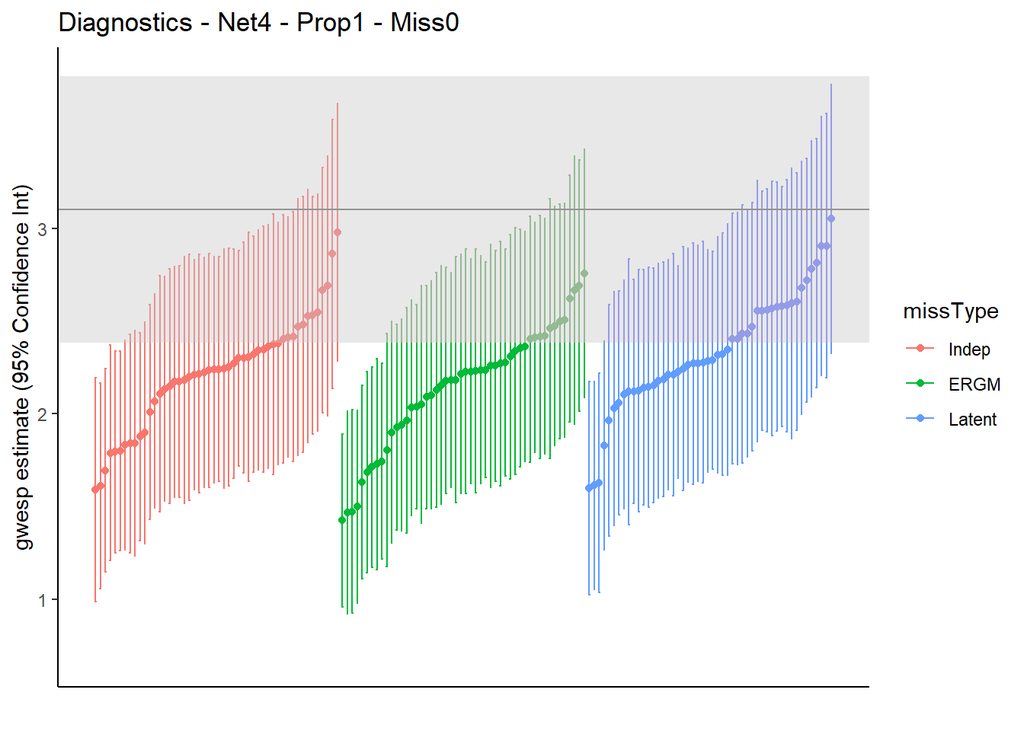

```r
# and see if the plot here matches the one above
missCaterpillarPlot(plotData = testPlotData,
                    truePara = tempTruePara,
                    trueSe = tempTrueSe,
                    chosenPara = "gwesp",
                    chosenNetInd = chosenNetInd,
                    chosenProp = 1,
                    chosenMiss = "0")
```

```r
# set a specific index for the network
chosenNetInd = 5

# file list for the chosen network index, change whenever necessary
chosenNetOutFiles = grep(paste("20231005_missNetReest_net", chosenNetInd, sep =""), outputList)

# loop to load
chosenNetOutList = outputList[chosenNetOutFiles]

for(fileInd in 1:length(chosenNetOutList)){
  # load all files
  load(here("Output", "20230825_simMissReest", "Todd", chosenNetOutList[fileInd]))

  # suppress these version difference warnings.
  suppressWarnings({
  modelResList[[fileInd]] = modelres$coefficients
  modelSeList[[fileInd]] = summary(modelres)$coefficients[,2]

  })

  # regex to get the first number after the specified text
  missModelList[[fileInd]] = as.integer(sub(".*?_missModel.*?(\\d+).*", "\\1", chosenNetOutList[[fileInd]]))
  propMissList[[fileInd]] = as.integer(sub(".*?_prop.*?(\\d+).*", "\\1", chosenNetOutList[[fileInd]]))
}

# first try with alt star
chosenPara = 2

tempTruePara = trueCoefList[[chosenNetInd]][chosenPara]
tempTrueSe = trueSeList[[chosenNetInd]][chosenPara]


# test run of the plot function
testPlotData = prepMissPlot(modelResList = modelResList,
                            modelSeList = modelSeList,
                            missModelList = missModelList,
                            propMissList = propMissList,
                            chosenProp = 1,
                            chosenPara = "altStar")

head(testPlotData)
```

```
##     parameter        SE missModel
## 1  -0.1933919 0.2208256     Indep
## 11 -0.1928590 0.2280006     Indep
## 7  -0.1823017 0.2226638     Indep
## 14 -0.1312494 0.2360561     Indep
## 15 -0.1227517 0.2318603     Indep
## 13 -0.1205444 0.2556446     Indep
```

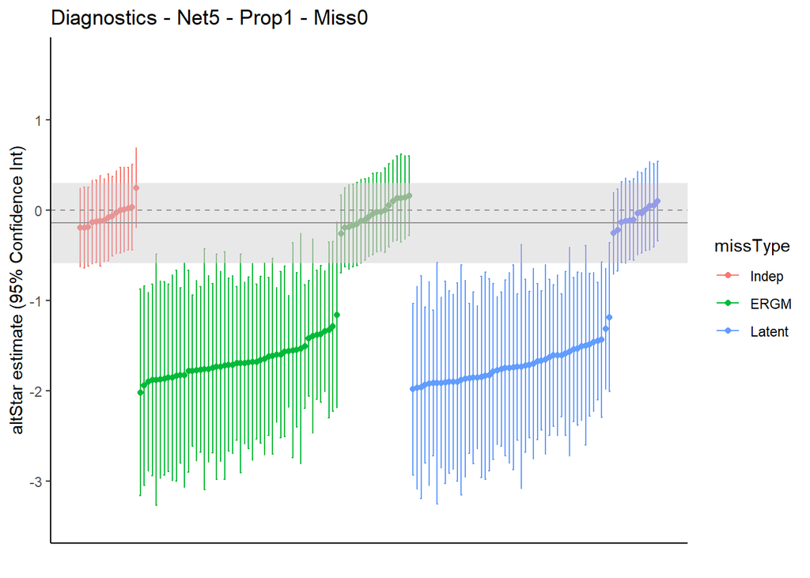

```r
# and see if the plot here matches the one above
missCaterpillarPlot(plotData = testPlotData,
                    truePara = tempTruePara,
                    trueSe = tempTrueSe,
                    chosenPara = "altStar",
                    chosenNetInd = chosenNetInd,
                    chosenProp = 1,
                    chosenMiss = "0")
```

```r
# still need to take out true parameter values
chosenPara = 3

tempTruePara = trueCoefList[[chosenNetInd]][chosenPara]
tempTrueSe = trueSeList[[chosenNetInd]][chosenPara]


# test run of the plot function
testPlotData = prepMissPlot(modelResList = modelResList,
                            modelSeList = modelSeList,
                            missModelList = missModelList,
                            propMissList = propMissList,
                            chosenProp = 1,
                            chosenPara = "gwesp")

head(testPlotData)
```

```
##    parameter        SE missModel
## 6   0.895099 0.2581558     Indep
## 9   1.169641 0.3098932     Indep
## 8   1.205350 0.3021720     Indep
## 5   1.214879 0.3145655     Indep
## 10  1.268217 0.3100610     Indep
## 4   1.294713 0.3410631     Indep
```

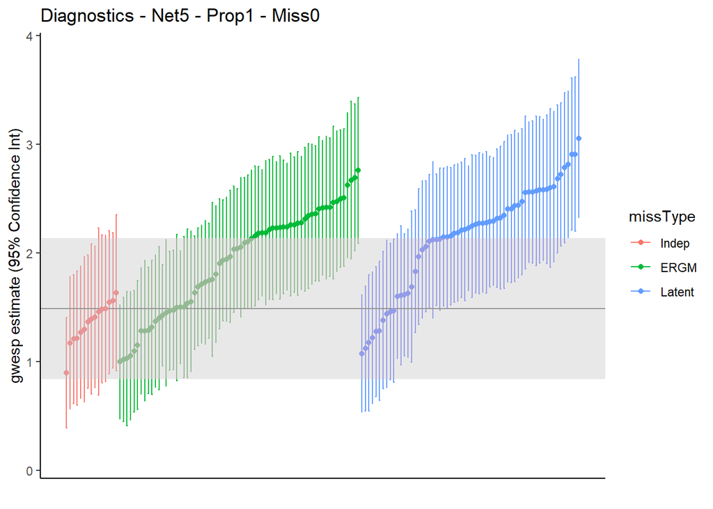

```r
# and see if the plot here matches the one above
missCaterpillarPlot(plotData = testPlotData,
                    truePara = tempTruePara,
                    trueSe = tempTrueSe,
                    chosenPara = "gwesp",
                    chosenNetInd = chosenNetInd,
                    chosenProp = 1,
                    chosenMiss = "0")
```

```r
# set a specific index for the network
chosenNetInd = 6

# file list for the chosen network index, change whenever necessary
chosenNetOutFiles = grep(paste("20231005_missNetReest_net", chosenNetInd, sep =""), outputList)

# loop to load
chosenNetOutList = outputList[chosenNetOutFiles]

for(fileInd in 1:length(chosenNetOutList)){
  # load all files
  load(here("Output", "20230825_simMissReest", "Todd", chosenNetOutList[fileInd]))

  # suppress these version difference warnings.
  suppressWarnings({
  modelResList[[fileInd]] = modelres$coefficients
  modelSeList[[fileInd]] = summary(modelres)$coefficients[,2]

  })

  # regex to get the first number after the specified text
  missModelList[[fileInd]] = as.integer(sub(".*?_missModel.*?(\\d+).*", "\\1", chosenNetOutList[[fileInd]]))
  propMissList[[fileInd]] = as.integer(sub(".*?_prop.*?(\\d+).*", "\\1", chosenNetOutList[[fileInd]]))
}

# first try with alt star
chosenPara = 2

tempTruePara = trueCoefList[[chosenNetInd]][chosenPara]
tempTrueSe = trueSeList[[chosenNetInd]][chosenPara]


# test run of the plot function
testPlotData = prepMissPlot(modelResList = modelResList,
                            modelSeList = modelSeList,
                            missModelList = missModelList,
                            propMissList = propMissList,
                            chosenProp = 1,
                            chosenPara = "altStar")

head(testPlotData)
```

```
##     parameter        SE missModel
## 20 0.08855555 0.4672493     Indep
## 10 0.10908395 0.4776949     Indep
## 9  0.19244928 0.4762694     Indep
## 17 0.27830005 0.4704765     Indep
## 46 0.29701442 0.4623967     Indep
## 42 0.30149274 0.4679391     Indep
```

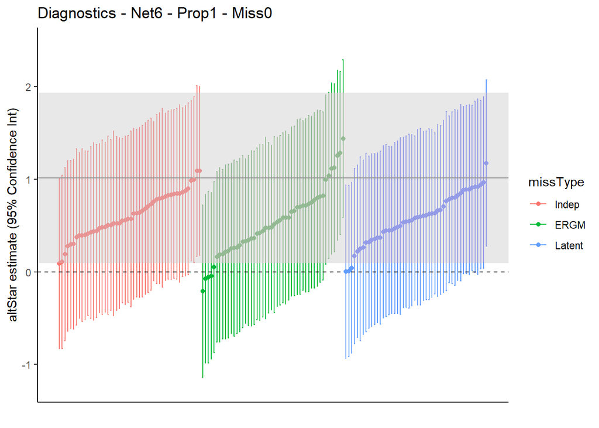

```r
# and see if the plot here matches the one above
missCaterpillarPlot(plotData = testPlotData,
                    truePara = tempTruePara,
                    trueSe = tempTrueSe,
                    chosenPara = "altStar",
                    chosenNetInd = chosenNetInd,
                    chosenProp = 1,
                    chosenMiss = "0")
```

```r
# still need to take out true parameter values
chosenPara = 3

tempTruePara = trueCoefList[[chosenNetInd]][chosenPara]
tempTrueSe = trueSeList[[chosenNetInd]][chosenPara]


# test run of the plot function
testPlotData = prepMissPlot(modelResList = modelResList,
                            modelSeList = modelSeList,
                            missModelList = missModelList,
                            propMissList = propMissList,
                            chosenProp = 1,
                            chosenPara = "gwesp")

head(testPlotData)
```

```
##    parameter        SE missModel
## 10 0.7096367 0.1369653     Indep
## 20 0.7855534 0.1535791     Indep
## 5  0.7991764 0.1535920     Indep
## 9  0.8701250 0.1602784     Indep
## 40 0.8728358 0.1610013     Indep
## 2  0.8749967 0.1523930     Indep
```

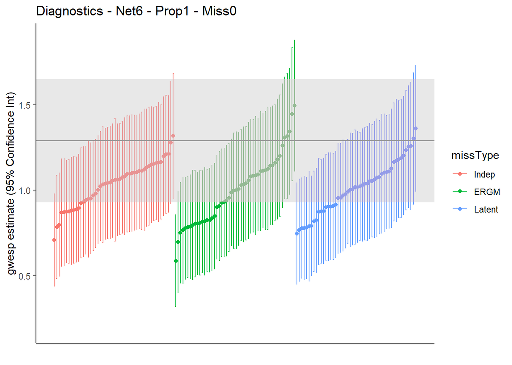

```r
# and see if the plot here matches the one above
missCaterpillarPlot(plotData = testPlotData,
                    truePara = tempTruePara,
                    trueSe = tempTrueSe,
                    chosenPara = "gwesp",
                    chosenNetInd = chosenNetInd,
                    chosenProp = 1,
                    chosenMiss = "0")
```

### 35% missingness - Peter

```r
# loading in the output results
outputList = list.files(here("Output", "20230825_simMissReest", "Peter"))

# set up some lists to put in the ergm re-estimations
modelResList = list()
modelSeList = list()
missModelList = list()
propMissList = list()

# set a specific index for the network
chosenNetInd = 2

# file list for the chosen network index, change whenever necessary
chosenNetOutFiles = grep(paste("20231004_missNetReest_net", chosenNetInd, sep =""), outputList)

# loop to load
chosenNetOutList = outputList[chosenNetOutFiles]

for(fileInd in 1:length(chosenNetOutList)){
  # load all files
  load(here("Output", "20230825_simMissReest", "Peter", chosenNetOutList[fileInd]))

  # suppress these version difference warnings.
  suppressWarnings({
  modelResList[[fileInd]] = modelres$coefficients
  modelSeList[[fileInd]] = summary(modelres)$coefficients[,2]

  })

  # regex to get the first number after the specified text
  missModelList[[fileInd]] = as.integer(sub(".*?_missModel.*?(\\d+).*", "\\1", chosenNetOutList[[fileInd]]))
  propMissList[[fileInd]] = as.integer(sub(".*?_prop.*?(\\d+).*", "\\1", chosenNetOutList[[fileInd]]))
}

# first try with alt star
chosenPara = 2

tempTruePara = trueCoefList[[chosenNetInd]][chosenPara]
tempTrueSe = trueSeList[[chosenNetInd]][chosenPara]


# test run of the plot function
testPlotData = prepMissPlot(modelResList = modelResList,
                            modelSeList = modelSeList,
                            missModelList = missModelList,
                            propMissList = propMissList,
                            chosenProp = 3,
                            chosenPara = "altStar")

head(testPlotData)
```

```
##    parameter       SE missModel
## 12 -4.558152 4.043885     Indep
## 14 -3.474548 2.506201     Indep
## 13 -3.227319 2.943347     Indep
## 1  -3.187661 2.242548     Indep
## 16 -2.702853 1.253112     Indep
## 15 -2.632289 1.020986     Indep
```

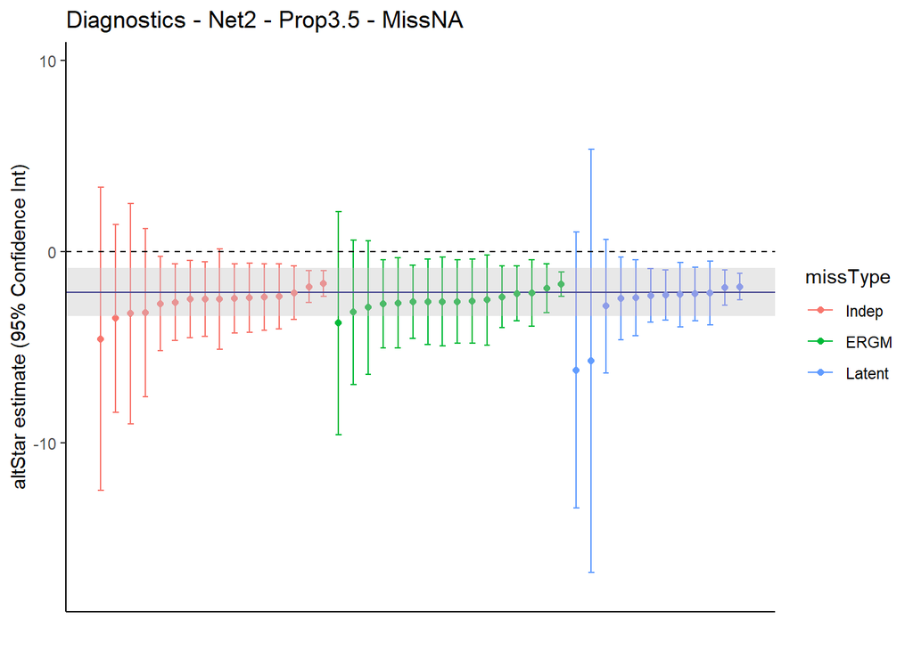

```r
# and see if the plot here matches the one above
missCaterpillarPlot(plotData = testPlotData,
                    truePara = tempTruePara,
                    trueSe = tempTrueSe,
                    chosenPara = "altStar",
                    chosenNetInd = chosenNetInd,
                    chosenProp = 3.5,
                    chosenMiss = "NA")
```

```r
# still need to take out true parameter values
chosenPara = 3

tempTruePara = trueCoefList[[chosenNetInd]][chosenPara]
tempTrueSe = trueSeList[[chosenNetInd]][chosenPara]


# test run of the plot function
testPlotData = prepMissPlot(modelResList = modelResList,
                            modelSeList = modelSeList,
                            missModelList = missModelList,
                            propMissList = propMissList,
                            chosenProp = 3,
                            chosenPara = "gwesp")

head(testPlotData)
```

```
##    parameter        SE missModel
## 4   3.323302 0.5682986     Indep
## 1   3.437627 0.6409324     Indep
## 14  3.484401 0.6621262     Indep
## 8   3.566714 0.6259340     Indep
## 3   3.696938 0.6449210     Indep
## 11  3.741881 0.6132945     Indep
```

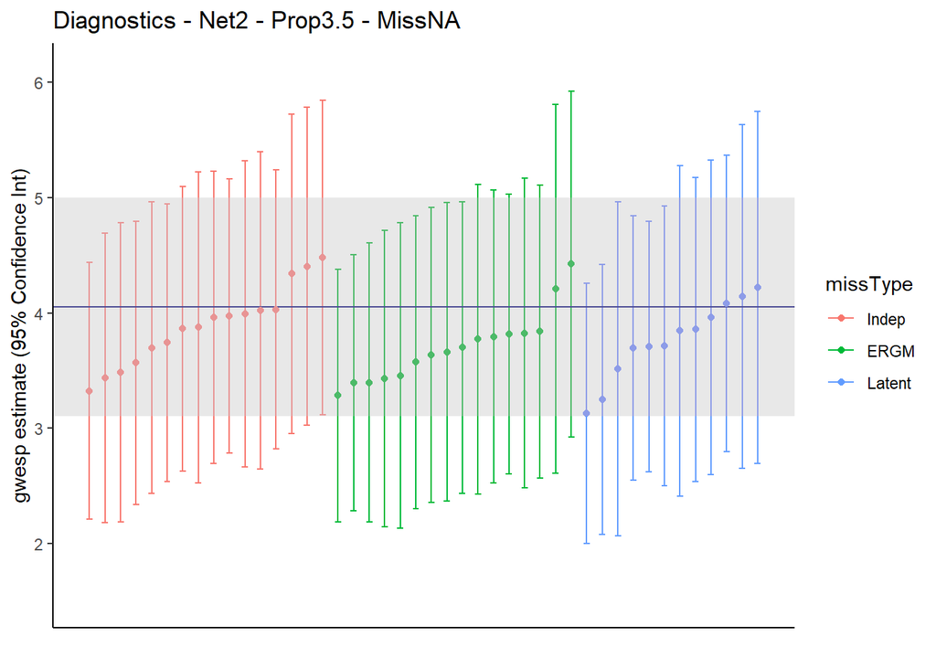

```r
# and see if the plot here matches the one above
missCaterpillarPlot(plotData = testPlotData,
                    truePara = tempTruePara,
                    trueSe = tempTrueSe,
                    chosenPara = "gwesp",
                    chosenNetInd = chosenNetInd,
                    chosenProp = 3.5,
                    chosenMiss = "NA")
```

```r
# set a specific index for the network
chosenNetInd = 4

# file list for the chosen network index, change whenever necessary
chosenNetOutFiles = grep(paste("20231004_missNetReest_net", chosenNetInd, sep =""), outputList)

# loop to load
chosenNetOutList = outputList[chosenNetOutFiles]

for(fileInd in 1:length(chosenNetOutList)){
  # load all files
  load(here("Output", "20230825_simMissReest", "Peter", chosenNetOutList[fileInd]))

  # suppress these version difference warnings.
  suppressWarnings({
  modelResList[[fileInd]] = modelres$coefficients
  modelSeList[[fileInd]] = summary(modelres)$coefficients[,2]

  })

  # regex to get the first number after the specified text
  missModelList[[fileInd]] = as.integer(sub(".*?_missModel.*?(\\d+).*", "\\1", chosenNetOutList[[fileInd]]))
  propMissList[[fileInd]] = as.integer(sub(".*?_prop.*?(\\d+).*", "\\1", chosenNetOutList[[fileInd]]))
}

# first try with alt star
chosenPara = 2

tempTruePara = trueCoefList[[chosenNetInd]][chosenPara]
tempTrueSe = trueSeList[[chosenNetInd]][chosenPara]


# test run of the plot function
testPlotData = prepMissPlot(modelResList = modelResList,
                            modelSeList = modelSeList,
                            missModelList = missModelList,
                            propMissList = propMissList,
                            chosenProp = 3,
                            chosenPara = "altStar")

head(testPlotData)
```

```
##    parameter       SE missModel
## 12 -3.536047 1.825336     Indep
## 23 -3.329675 2.333945     Indep
## 18 -2.818693 1.409608     Indep
## 37 -2.728979 1.230028     Indep
## 34 -2.644825 1.234967     Indep
## 10 -2.596926 1.057250     Indep
```

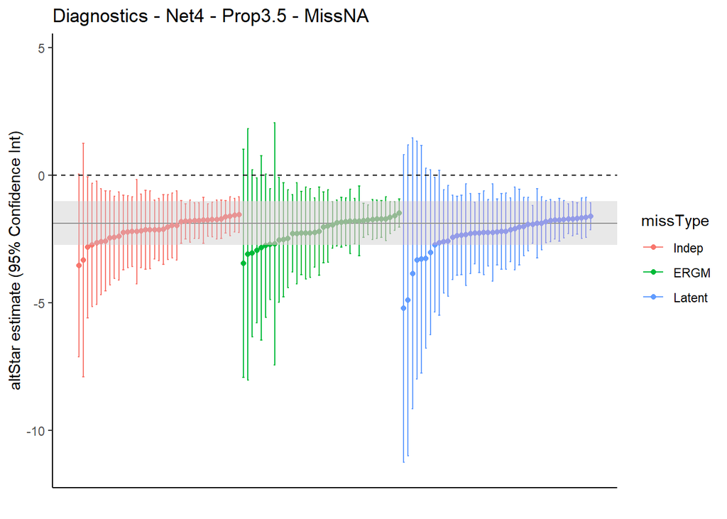

```r
# and see if the plot here matches the one above
missCaterpillarPlot(plotData = testPlotData,
                    truePara = tempTruePara,
                    trueSe = tempTrueSe,
                    chosenPara = "altStar",
                    chosenNetInd = chosenNetInd,
                    chosenProp = 3.5,
                    chosenMiss = "NA")
```

```r
# still need to take out true parameter values
chosenPara = 3

tempTruePara = trueCoefList[[chosenNetInd]][chosenPara]
tempTrueSe = trueSeList[[chosenNetInd]][chosenPara]


# test run of the plot function
testPlotData = prepMissPlot(modelResList = modelResList,
                            modelSeList = modelSeList,
                            missModelList = missModelList,
                            propMissList = propMissList,
                            chosenProp = 3,
                            chosenPara = "gwesp")

head(testPlotData)
```

```
##    parameter        SE missModel
## 3   2.497359 0.4892193     Indep
## 7   2.510058 0.4429165     Indep
## 30  2.617554 0.5050321     Indep
## 2   2.640901 0.5463155     Indep
## 27  2.712829 0.4962674     Indep
## 13  2.731805 0.4496286     Indep
```

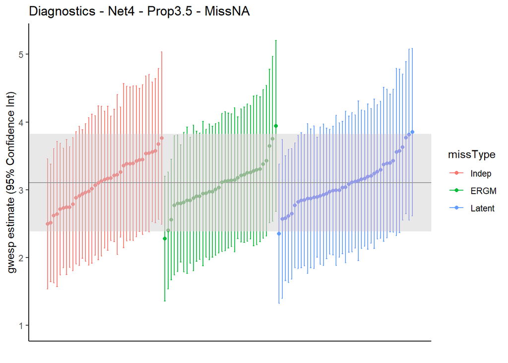

```r
# and see if the plot here matches the one above
missCaterpillarPlot(plotData = testPlotData,
                    truePara = tempTruePara,
                    trueSe = tempTrueSe,
                    chosenPara = "gwesp",
                    chosenNetInd = chosenNetInd,
                    chosenProp = 3.5,
                    chosenMiss = "NA")
```